# Final Project

Steven Mann

8/13/2020

#Read in the Data

```r
CaseStudy = read.csv(file.choose(),header=TRUE,stringsAsFactors = TRUE)
NoAttrition = read.csv(file.choose(),header = TRUE, stringsAsFactors = TRUE)
NoSalary = read.csv(file.choose(),header = TRUE, stringsAsFactors = TRUE)
```

#Load in the Libraries

```r
library(tidyverse)
```

```r
library(ggplot2)
library(caret)
library(e1071)
library(leaps)
library(stats)
library(rsq)
library(Metrics)
library(kknn)
```

##Create factor variables out of variables brought in as integers

```r
names <- c('RelationshipSatisfaction','PerformanceRating','WorkLifeBalance',
           'JobInvolvement','JobSatisfaction','JobLevel','StockOptionLevel',
           'Education','EnvironmentSatisfaction')

CaseStudy[,names] <- lapply(CaseStudy[,names],factor,ordered = TRUE)
NoAttrition[,names] <- lapply(NoAttrition[,names],factor,ordered = TRUE)
NoSalary[,names] <- lapply(NoSalary[,names],factor,ordered = TRUE)
```

#Create new variable for job OT

```r
CaseStudy <- CaseStudy %>% mutate(JobRole_OT = paste(JobRole,OverTime,sep = "_"))
CaseStudy$JobRole_OT = as.factor(CaseStudy$JobRole_OT)
NoSalary <- NoSalary %>% mutate(JobRole_OT = paste(JobRole,OverTime,sep = "_"))
NoSalary$JobRole_OT = as.factor(NoSalary$JobRole_OT)
```

#Create categorical variable for Monthly Income based on summary statistics

```r
IncomeSum = summary(CaseStudy$MonthlyIncome)
CaseStudy$MonthlyIncomeHL = as.factor(if_else(CaseStudy$MonthlyIncome <= IncomeSum[2],"Lowest",
                                    if_else(CaseStudy$MonthlyIncome <= IncomeSum[3],"Medium/Low",
                                            if_else(CaseStudy$MonthlyIncome <= IncomeSum[4],"Medium/High","High"))))
```

```r
TotalWorkSum = summary(CaseStudy$TotalWorkingYears)
CaseStudy$TotalWorkHL = as.factor(if_else(CaseStudy$TotalWorkingYears <= TotalWorkSum[2],"<=6",
                                  if_else(CaseStudy$TotalWorkingYears <= TotalWorkSum[3],"6< <=10",
                                          if_else(CaseStudy$TotalWorkingYears <= TotalWorkSum[5],"10< <=15",">15"))))
```

```r
CaseStudyClean <- CaseStudy[,c("Attrition","JobRole_OT","MonthlyIncomeHL","JobInvolvement","WorkLifeBalance","TotalWorkHL",
                            "JobLevel","StockOptionLevel","MaritalStatus","Gender")]
```

##Pie chart for overall attrition rate

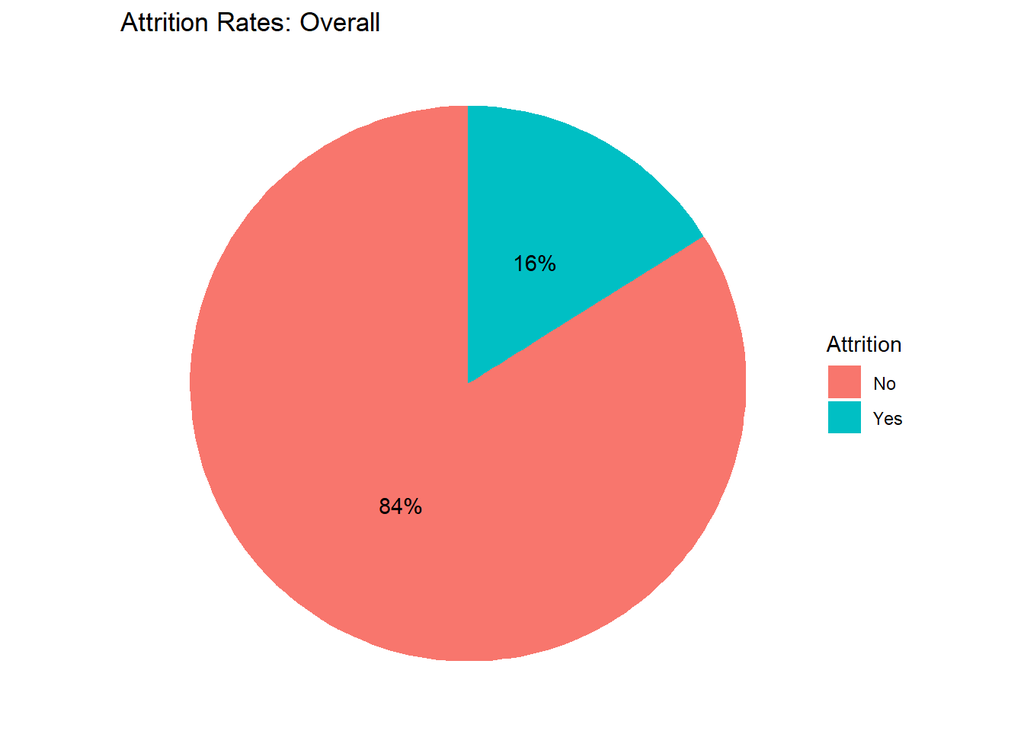

```r
data <- data.frame(a=CaseStudy$Attrition)
data <- data %>%
  group_by(a) %>%
  count() %>%
  ungroup() %>%
  mutate(per=`n`/sum(`n`)) %>%
  arrange(desc(a))
data$label <- scales::percent(data$per)
ggplot(data=data)+
  geom_bar(aes(x="", y=per, fill=a), stat="identity", width = 1)+
  coord_polar("y", start=0)+
  theme_void()+
  geom_text(aes(x=1, y = cumsum(per) - per/2, label=label)) +
  labs(title = "Attrition Rates: Overall",fill = "Attrition")
```

#Split into Job Involvement Subsets for Plotting

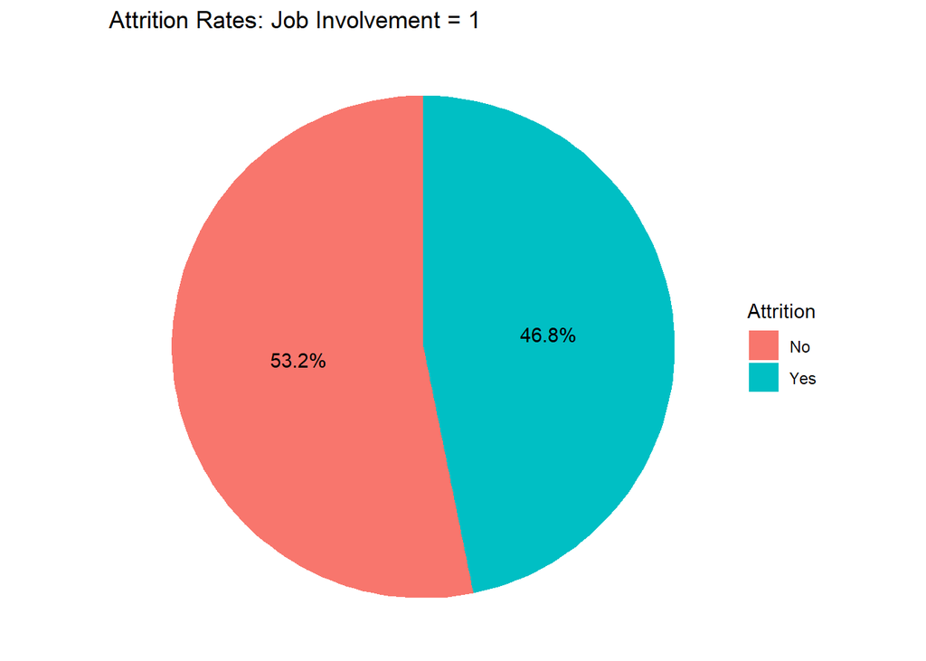

```r
Involvement1 = CaseStudy %>% filter(JobInvolvement == 1)
Involvement2 = CaseStudy %>% filter(JobInvolvement == 2)
Involvement3 = CaseStudy %>% filter(JobInvolvement == 3)
Involvement4 = CaseStudy %>% filter(JobInvolvement == 4)

#Plot Pie chart for Job Involvement = 1
data <- data.frame(a=Involvement1$Attrition)
data <- data %>%
  group_by(a) %>%
  count() %>%
  ungroup() %>%
  mutate(per=`n`/sum(`n`)) %>%
  arrange(desc(a))
data$label <- scales::percent(data$per)
ggplot(data=data)+
  geom_bar(aes(x="", y=per, fill=a), stat="identity", width = 1)+
  coord_polar("y", start=0)+
  theme_void()+
  geom_text(aes(x=1, y = cumsum(per) - per/2, label=label)) +
  labs(title = "Attrition Rates: Job Involvement = 1",fill = "Attrition")
```

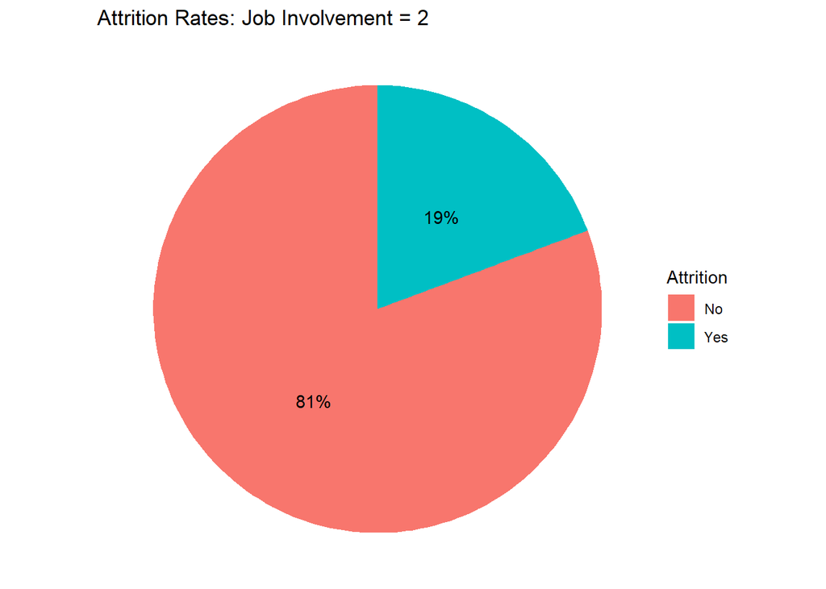

```r
#Plot Pie chart for Job Involvement = 2
data <- data.frame(a=Involvement2$Attrition)
data <- data %>%
  group_by(a) %>%
  count() %>%
  ungroup() %>%
  mutate(per=`n`/sum(`n`)) %>%
  arrange(desc(a))
data$label <- scales::percent(data$per)
ggplot(data=data)+
  geom_bar(aes(x="", y=per, fill=a), stat="identity", width = 1)+
  coord_polar("y", start=0)+
  theme_void()+
  geom_text(aes(x=1, y = cumsum(per) - per/2, label=label)) +
  labs(title = "Attrition Rates: Job Involvement = 2",fill = "Attrition")
```

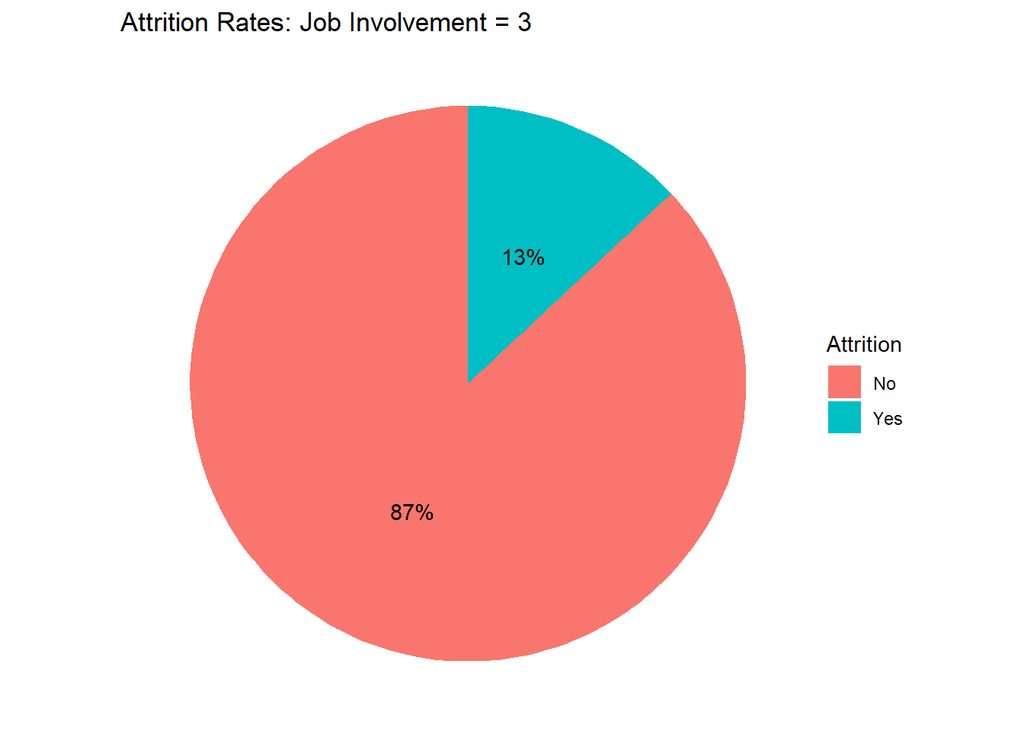

```r
#Plot Pie chart for Job Involvement = 3
data <- data.frame(a=Involvement3$Attrition)
data <- data %>%
  group_by(a) %>%
  count() %>%
  ungroup() %>%
  mutate(per=`n`/sum(`n`)) %>%
  arrange(desc(a))
data$label <- scales::percent(data$per)
ggplot(data=data)+
  geom_bar(aes(x="", y=per, fill=a), stat="identity", width = 1)+
  coord_polar("y", start=0)+
  theme_void()+
  geom_text(aes(x=1, y = cumsum(per) - per/2, label=label)) +
  labs(title = "Attrition Rates: Job Involvement = 3",fill = "Attrition")
```

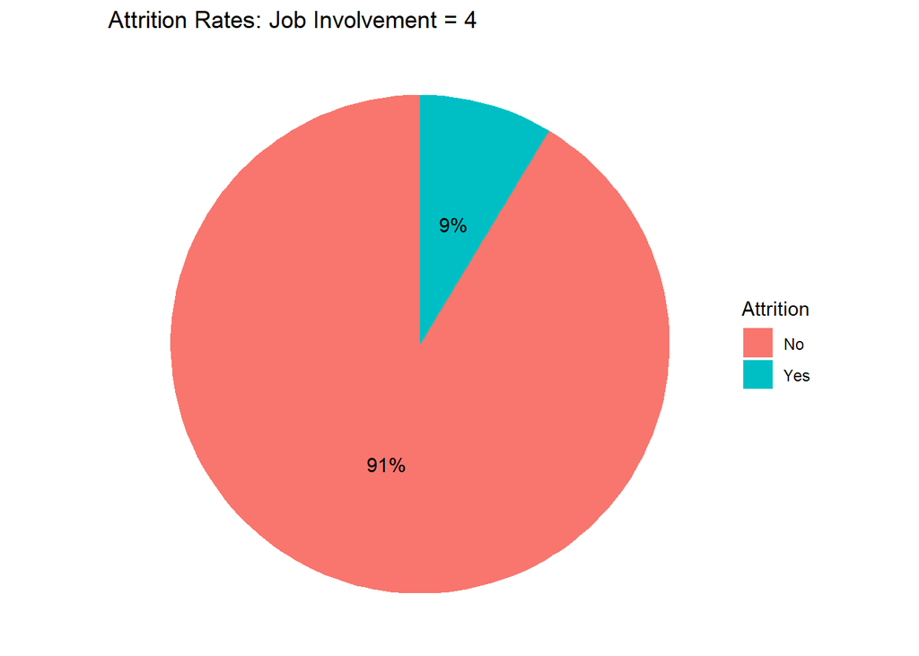

```r
#Plot Pie chart for Job Involvement = 4
data <- data.frame(a=Involvement4$Attrition)
data <- data %>%
  group_by(a) %>%
  count() %>%
  ungroup() %>%
  mutate(per=`n`/sum(`n`)) %>%
  arrange(desc(a))
data$label <- scales::percent(data$per)
ggplot(data=data)+
  geom_bar(aes(x="", y=per, fill=a), stat="identity", width = 1)+
  coord_polar("y", start=0)+
  theme_void()+
  geom_text(aes(x=1, y = cumsum(per) - per/2, label=label)) +
  labs(title = "Attrition Rates: Job Involvement = 4",fill = "Attrition")
```

#Split into Job Level Subsets for Plotting

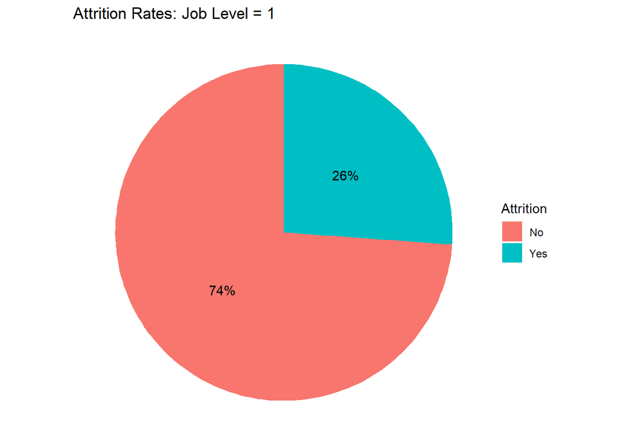

```r
Level1 = CaseStudy %>% filter(JobLevel == 1)
Level2 = CaseStudy %>% filter(JobLevel == 2)
Level3 = CaseStudy %>% filter(JobLevel == 3)
Level4 = CaseStudy %>% filter(JobLevel == 4)
Level5 = CaseStudy %>% filter(JobLevel == 5)

#Plot Pie chart for Job Level = 1
data <- data.frame(a=Level1$Attrition)
data <- data %>%
  group_by(a) %>%
  count() %>%
  ungroup() %>%
  mutate(per=`n`/sum(`n`)) %>%
  arrange(desc(a))
data$label <- scales::percent(data$per)
ggplot(data=data)+
  geom_bar(aes(x="", y=per, fill=a), stat="identity", width = 1)+
  coord_polar("y", start=0)+
  theme_void()+
  geom_text(aes(x=1, y = cumsum(per) - per/2, label=label)) +
  labs(title = "Attrition Rates: Job Level = 1",fill = "Attrition")
```

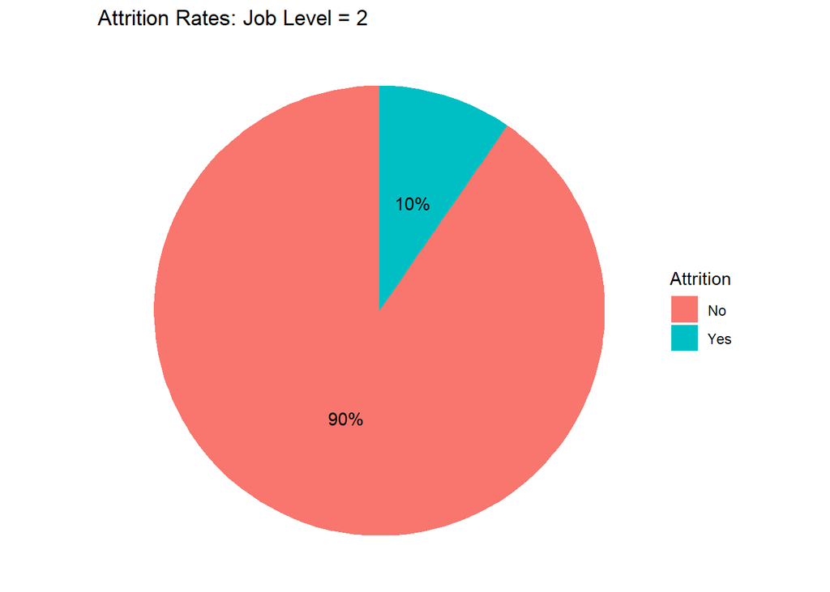

```r
#Plot Pie chart for Job Level = 2
data <- data.frame(a=Level2$Attrition)
data <- data %>%
  group_by(a) %>%
  count() %>%
  ungroup() %>%
  mutate(per=`n`/sum(`n`)) %>%
  arrange(desc(a))
data$label <- scales::percent(data$per)
ggplot(data=data)+
  geom_bar(aes(x="", y=per, fill=a), stat="identity", width = 1)+
  coord_polar("y", start=0)+
  theme_void()+
  geom_text(aes(x=1, y = cumsum(per) - per/2, label=label)) +
  labs(title = "Attrition Rates: Job Level = 2",fill = "Attrition")
```

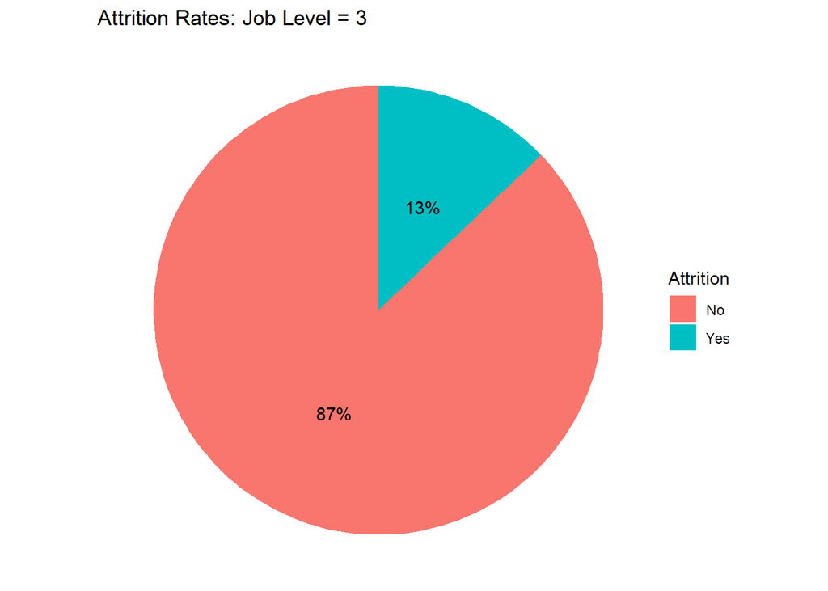

```r
#Plot Pie chart for Job Level = 3
data <- data.frame(a=Level3$Attrition)
data <- data %>%
  group_by(a) %>%
  count() %>%
  ungroup() %>%
  mutate(per=`n`/sum(`n`)) %>%
  arrange(desc(a))
data$label <- scales::percent(data$per)
ggplot(data=data)+
  geom_bar(aes(x="", y=per, fill=a), stat="identity", width = 1)+
  coord_polar("y", start=0)+
  theme_void()+
  geom_text(aes(x=1, y = cumsum(per) - per/2, label=label)) +
  labs(title = "Attrition Rates: Job Level = 3",fill = "Attrition")
```

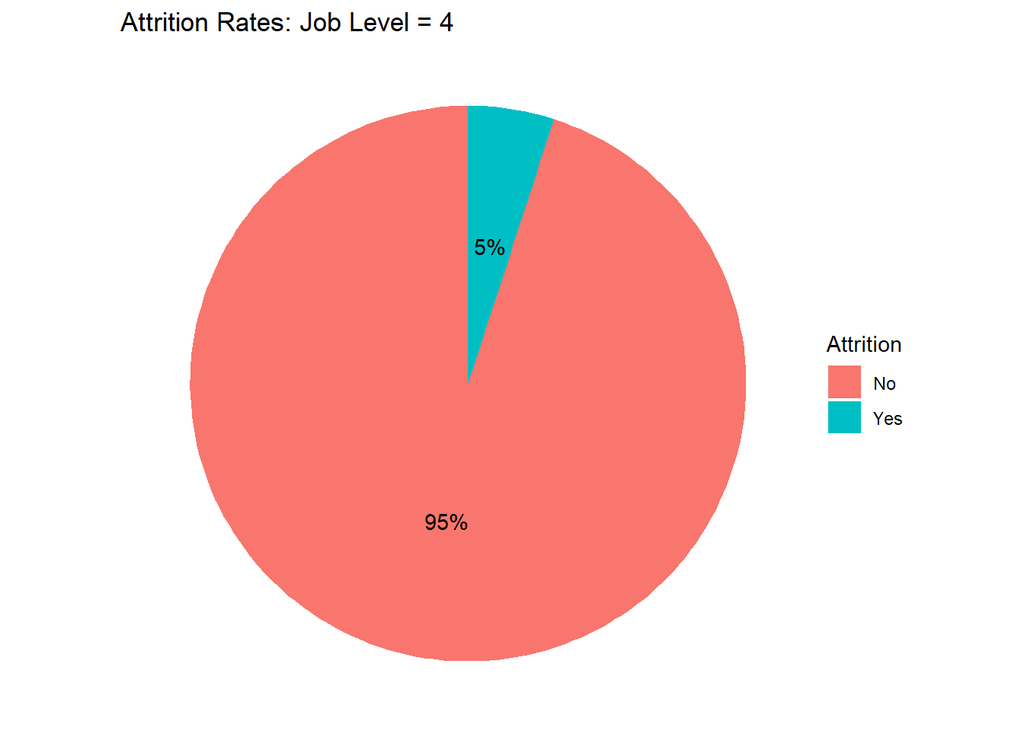

```r
#Plot Pie chart for Job Level = 4
data <- data.frame(a=Level4$Attrition)
data <- data %>%
  group_by(a) %>%
  count() %>%
  ungroup() %>%
  mutate(per=`n`/sum(`n`)) %>%
  arrange(desc(a))
data$label <- scales::percent(data$per)
ggplot(data=data)+
  geom_bar(aes(x="", y=per, fill=a), stat="identity", width = 1)+
  coord_polar("y", start=0)+
  theme_void()+
  geom_text(aes(x=1, y = cumsum(per) - per/2, label=label)) +
  labs(title = "Attrition Rates: Job Level = 4",fill = "Attrition")
```

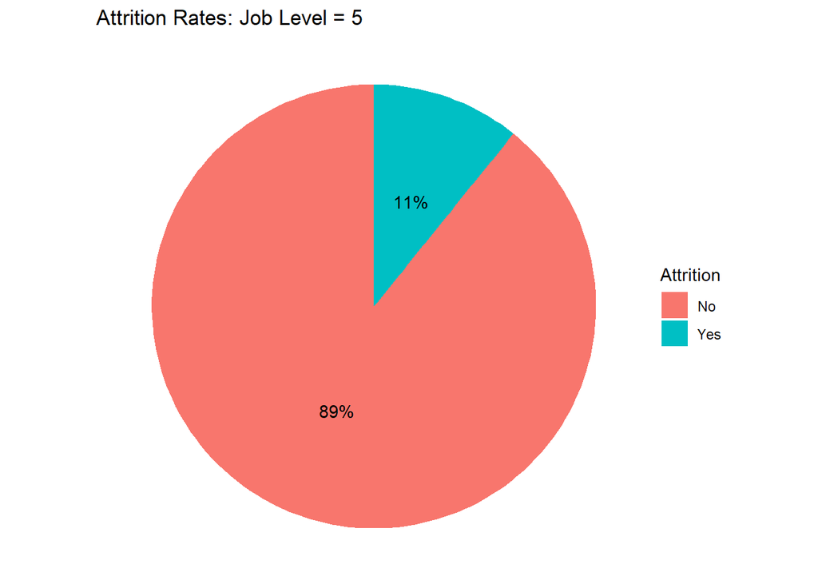

```r
#Plot Pie chart for Job Level = 5
data <- data.frame(a=Level5$Attrition)
data <- data %>%
  group_by(a) %>%
  count() %>%
  ungroup() %>%
  mutate(per=`n`/sum(`n`)) %>%
  arrange(desc(a))
data$label <- scales::percent(data$per)
ggplot(data=data)+
  geom_bar(aes(x="", y=per, fill=a), stat="identity", width = 1)+
  coord_polar("y", start=0)+
  theme_void()+
  geom_text(aes(x=1, y = cumsum(per) - per/2, label=label)) +
  labs(title = "Attrition Rates: Job Level = 5",fill = "Attrition")
```

##JobRole_OT Data

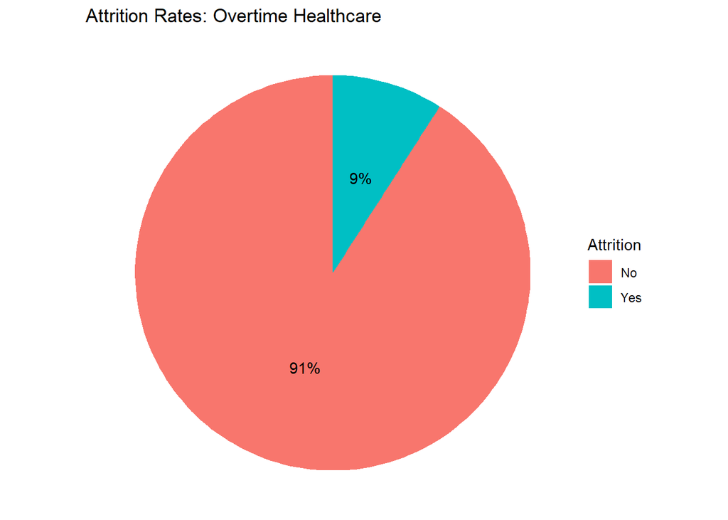

```r
#Split into Job ROle Subsets for Plotting
Healthcare = CaseStudy %>% filter(JobRole == "Healthcare Representative")
HRRole = CaseStudy %>% filter(JobRole == "Human Resources")
Lab = CaseStudy %>% filter(JobRole == "Laboratory Technician")
Manager = CaseStudy %>% filter(JobRole == "Manager")
Manu = CaseStudy %>% filter(JobRole == "Manufacturing Director")
ResearchDirector = CaseStudy %>% filter(JobRole == "Research Director")
ResearchScientist = CaseStudy %>% filter(JobRole == "Research Scientist")
SalesExec = CaseStudy %>% filter(JobRole == "Sales Executive")
SalesRep = CaseStudy %>% filter(JobRole == "Sales Representative")

#Split into Overtime Status Subsets for Plotting
NOOT = CaseStudy %>% filter(OverTime == "No")
OT = CaseStudy %>% filter(OverTime == "Yes")

#Split into Job ROle & OT Status Subsets for Plotting
HealthcareOT = CaseStudy %>% filter(JobRole_OT == "Healthcare Representative_Yes")
HealthcareNOOT = CaseStudy %>% filter(JobRole_OT == "Healthcare Representative_No")
HRRoleOT = CaseStudy %>% filter(JobRole_OT == "Human Resources_Yes")
HRRoleNOOT = CaseStudy %>% filter(JobRole_OT == "Human Resources_No")
LabOT = CaseStudy %>% filter(JobRole_OT == "Laboratory Technician_Yes")
LabNOOT = CaseStudy %>% filter(JobRole_OT == "Laboratory Technician_No")
ManagerOT = CaseStudy %>% filter(JobRole_OT == "Manager_Yes")
ManagerNOOT = CaseStudy %>% filter(JobRole_OT == "Manager_No")
ManuOT = CaseStudy %>% filter(JobRole_OT == "Manufacturing Director_Yes")
ManuNOOT = CaseStudy %>% filter(JobRole_OT == "Manufacturing Director_No")
ResearchDirectorOT = CaseStudy %>% filter(JobRole_OT == "Research Director_Yes")
ResearchDirectorNOOT = CaseStudy %>% filter(JobRole_OT == "Research Director_No")
ResearchScientistOT = CaseStudy %>% filter(JobRole_OT == "Research Scientist_Yes")
ResearchScientistNOOT = CaseStudy %>% filter(JobRole_OT == "Research Scientist_No")
SalesExecOT = CaseStudy %>% filter(JobRole_OT == "Sales Executive_Yes")
SalesExecNOOT = CaseStudy %>% filter(JobRole_OT == "Sales Executive_No")
SalesRepOT = CaseStudy %>% filter(JobRole_OT == "Sales Representative_Yes")
SalesRepNOOT = CaseStudy %>% filter(JobRole_OT == "Sales Representative_No")

#Plot Pie charts for Healthcare
#OT
data <- data.frame(a=HealthcareOT$Attrition)
data <- data %>%
  group_by(a) %>%
  count() %>%
  ungroup() %>%
  mutate(per=`n`/sum(`n`)) %>%
  arrange(desc(a))
data$label <- scales::percent(data$per)
ggplot(data=data)+
  geom_bar(aes(x="", y=per, fill=a), stat="identity", width = 1)+
  coord_polar("y", start=0)+
  theme_void()+
  geom_text(aes(x=1, y = cumsum(per) - per/2, label=label)) +
  labs(title = "Attrition Rates: Overtime Healthcare",fill = "Attrition")
```

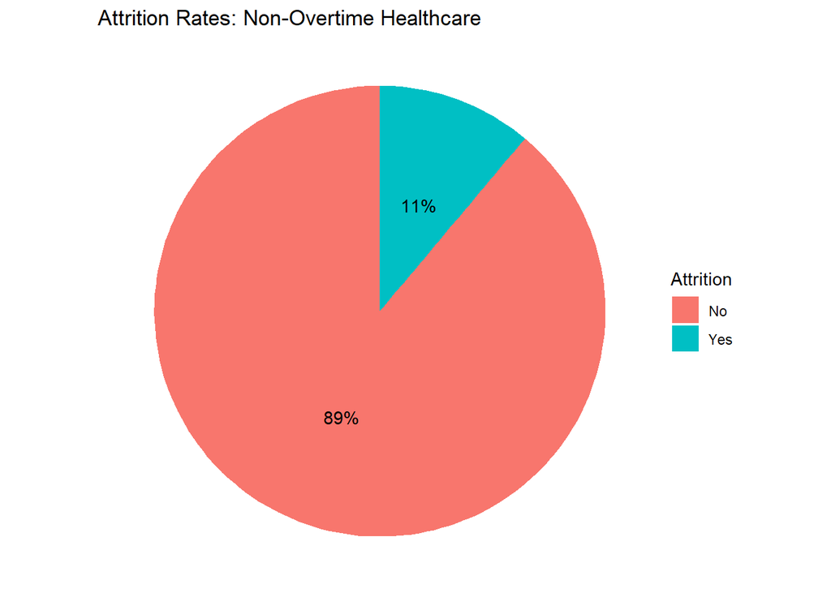

```r
#No OT
data <- data.frame(a=HealthcareNOOT$Attrition)
data <- data %>%
  group_by(a) %>%
  count() %>%
  ungroup() %>%
  mutate(per=`n`/sum(`n`)) %>%
  arrange(desc(a))
data$label <- scales::percent(data$per)
ggplot(data=data)+
  geom_bar(aes(x="", y=per, fill=a), stat="identity", width = 1)+
  coord_polar("y", start=0)+
  theme_void()+
  geom_text(aes(x=1, y = cumsum(per) - per/2, label=label)) +
  labs(title = "Attrition Rates: Non-Overtime Healthcare",fill = "Attrition")
```

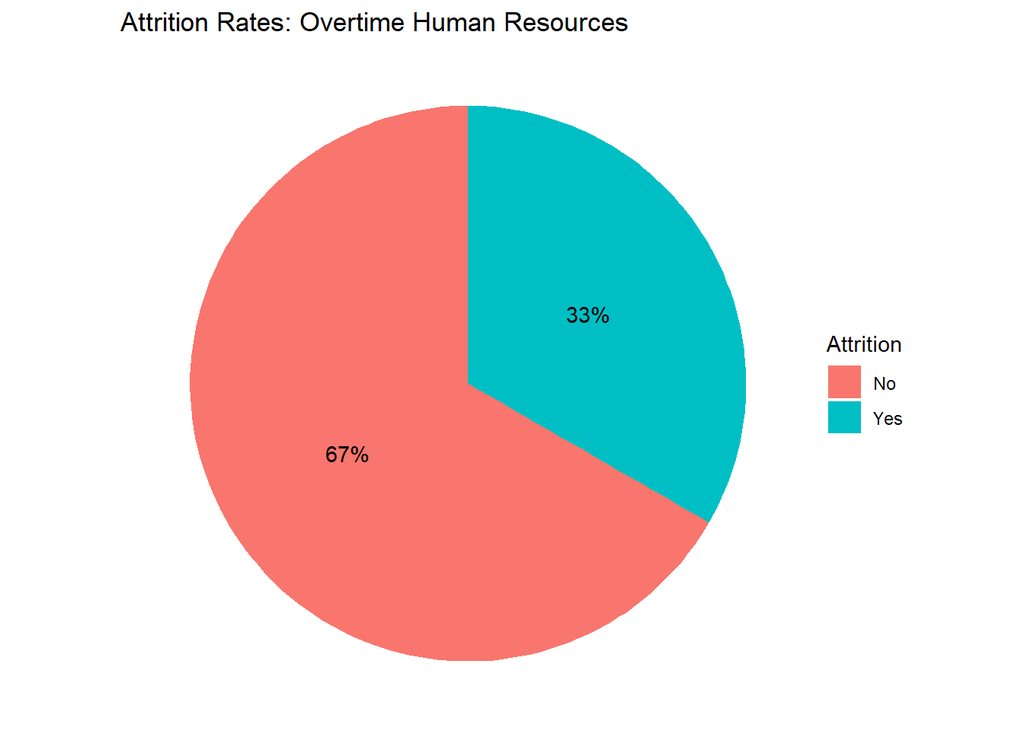

```r
#Plot Pie charts for HR
#OT
data <- data.frame(a=HRRoleOT$Attrition)
data <- data %>%
  group_by(a) %>%
  count() %>%
  ungroup() %>%
  mutate(per=`n`/sum(`n`)) %>%
  arrange(desc(a))
data$label <- scales::percent(data$per)
ggplot(data=data)+
  geom_bar(aes(x="", y=per, fill=a), stat="identity", width = 1)+
  coord_polar("y", start=0)+
  theme_void()+
  geom_text(aes(x=1, y = cumsum(per) - per/2, label=label)) +
  labs(title = "Attrition Rates: Overtime Human Resources",fill = "Attrition")
```

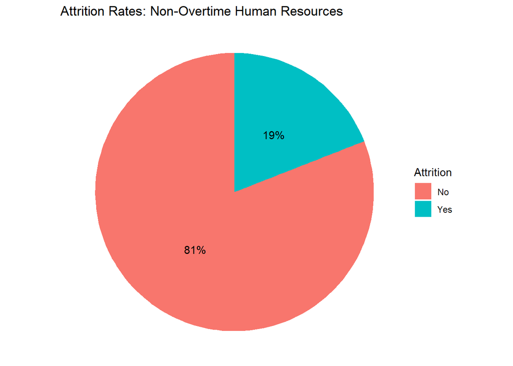

```r
#No OT
data <- data.frame(a=HRRoleNOOT$Attrition)
data <- data %>%
  group_by(a) %>%
  count() %>%
  ungroup() %>%
  mutate(per=`n`/sum(`n`)) %>%
  arrange(desc(a))
data$label <- scales::percent(data$per)
ggplot(data=data)+
  geom_bar(aes(x="", y=per, fill=a), stat="identity", width = 1)+
  coord_polar("y", start=0)+
  theme_void()+
  geom_text(aes(x=1, y = cumsum(per) - per/2, label=label)) +
  labs(title = "Attrition Rates: Non-Overtime Human Resources",fill = "Attrition")
```

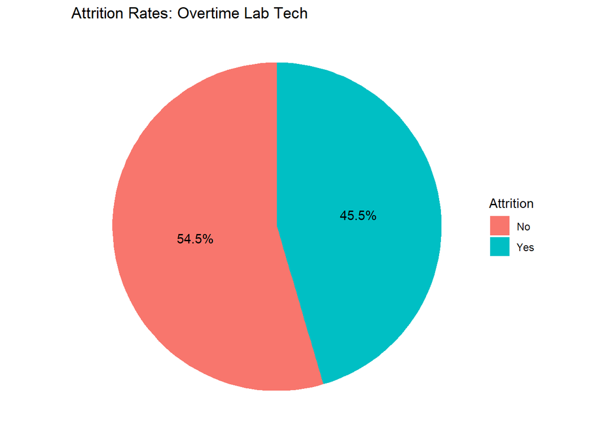

```r
#Plot Pie charts for Lab Tech
#OT
data <- data.frame(a=LabOT$Attrition)
data <- data %>%
  group_by(a) %>%
  count() %>%
  ungroup() %>%
  mutate(per=`n`/sum(`n`)) %>%
  arrange(desc(a))
data$label <- scales::percent(data$per)
ggplot(data=data)+
  geom_bar(aes(x="", y=per, fill=a), stat="identity", width = 1)+
  coord_polar("y", start=0)+
  theme_void()+
  geom_text(aes(x=1, y = cumsum(per) - per/2, label=label)) +
  labs(title = "Attrition Rates: Overtime Lab Tech",fill = "Attrition")
```

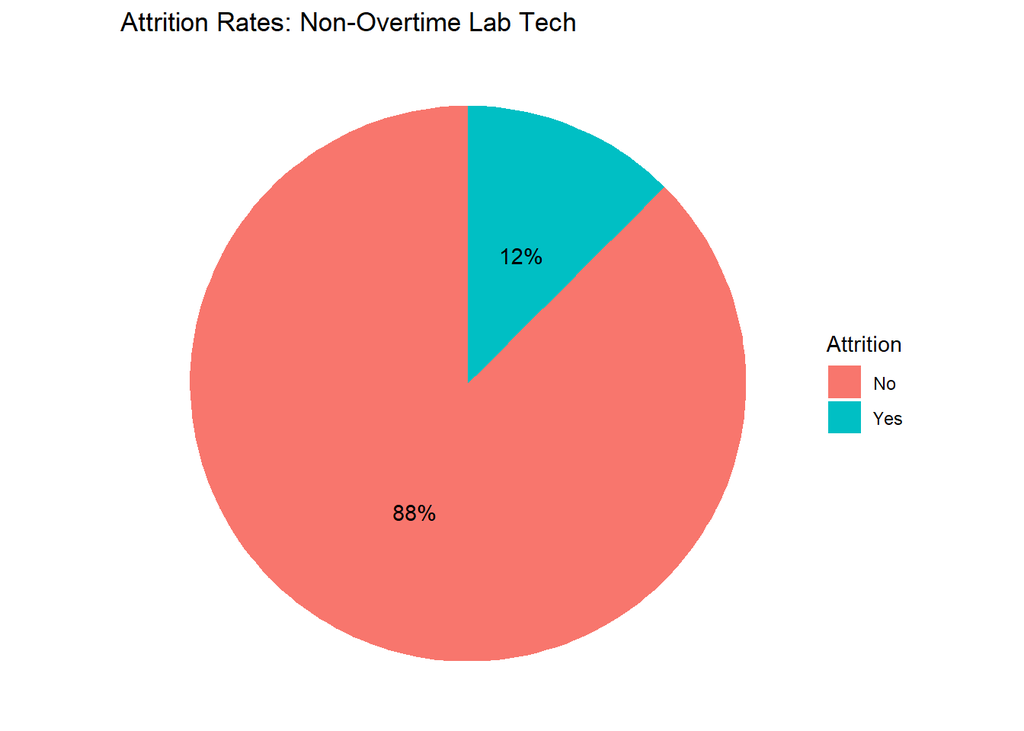

```r
#No OT
data <- data.frame(a=LabNOOT$Attrition)
data <- data %>%
  group_by(a) %>%
  count() %>%
  ungroup() %>%
  mutate(per=`n`/sum(`n`)) %>%
  arrange(desc(a))
data$label <- scales::percent(data$per)
ggplot(data=data)+
  geom_bar(aes(x="", y=per, fill=a), stat="identity", width = 1)+
  coord_polar("y", start=0)+
  theme_void()+
  geom_text(aes(x=1, y = cumsum(per) - per/2, label=label)) +
  labs(title = "Attrition Rates: Non-Overtime Lab Tech",fill = "Attrition")
```

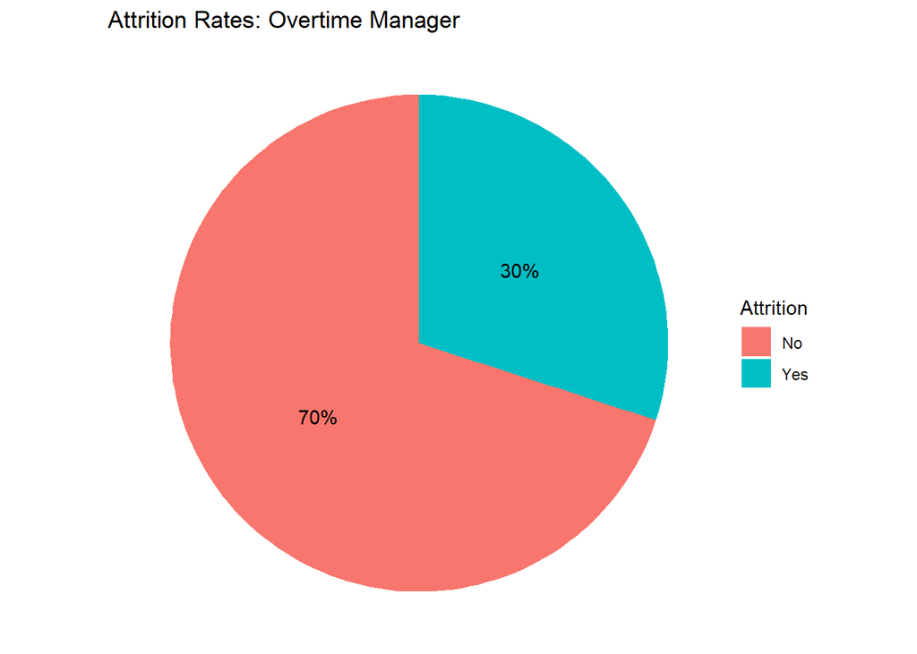

```r
#Plot Pie charts for Manager
#OT
data <- data.frame(a=ManagerOT$Attrition)
data <- data %>%
  group_by(a) %>%
  count() %>%
  ungroup() %>%
  mutate(per=`n`/sum(`n`)) %>%
  arrange(desc(a))
data$label <- scales::percent(data$per)
ggplot(data=data)+
  geom_bar(aes(x="", y=per, fill=a), stat="identity", width = 1)+
  coord_polar("y", start=0)+
  theme_void()+
  geom_text(aes(x=1, y = cumsum(per) - per/2, label=label)) +
  labs(title = "Attrition Rates: Overtime Manager",fill = "Attrition")
```

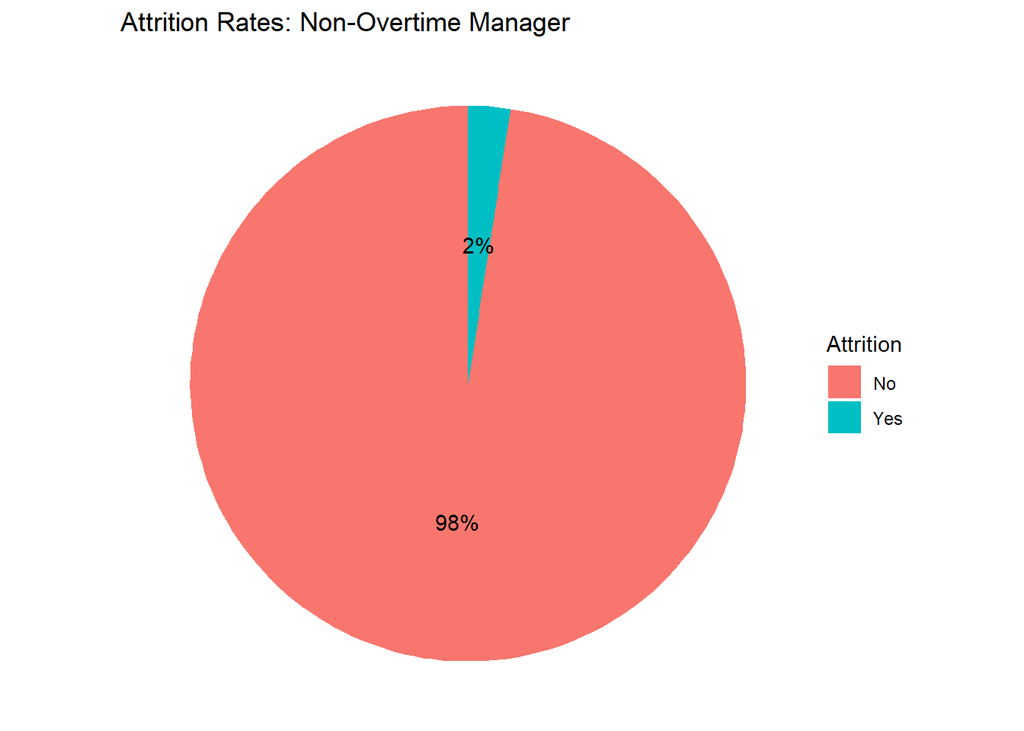

```r
#No OT
data <- data.frame(a=ManagerNOOT$Attrition)
data <- data %>%
  group_by(a) %>%
  count() %>%
  ungroup() %>%
  mutate(per=`n`/sum(`n`)) %>%
  arrange(desc(a))
data$label <- scales::percent(data$per)
ggplot(data=data)+
  geom_bar(aes(x="", y=per, fill=a), stat="identity", width = 1)+
  coord_polar("y", start=0)+
  theme_void()+
  geom_text(aes(x=1, y = cumsum(per) - per/2, label=label)) +
  labs(title = "Attrition Rates: Non-Overtime Manager",fill = "Attrition")
```

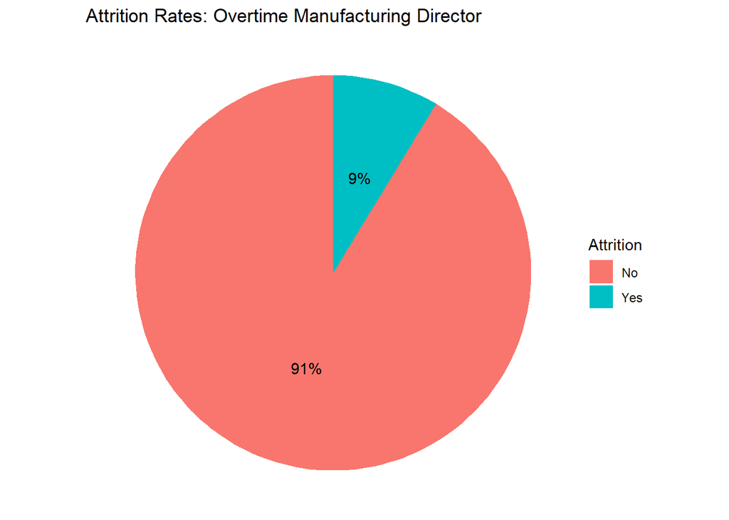

```r
#Plot Pie charts for Manufacturing Director
#OT
data <- data.frame(a=ManuOT$Attrition)
data <- data %>%
  group_by(a) %>%
  count() %>%
  ungroup() %>%
  mutate(per=`n`/sum(`n`)) %>%
  arrange(desc(a))
data$label <- scales::percent(data$per)
ggplot(data=data)+
  geom_bar(aes(x="", y=per, fill=a), stat="identity", width = 1)+
  coord_polar("y", start=0)+
  theme_void()+
  geom_text(aes(x=1, y = cumsum(per) - per/2, label=label)) +
  labs(title = "Attrition Rates: Overtime Manufacturing Director",fill = "Attrition")
```

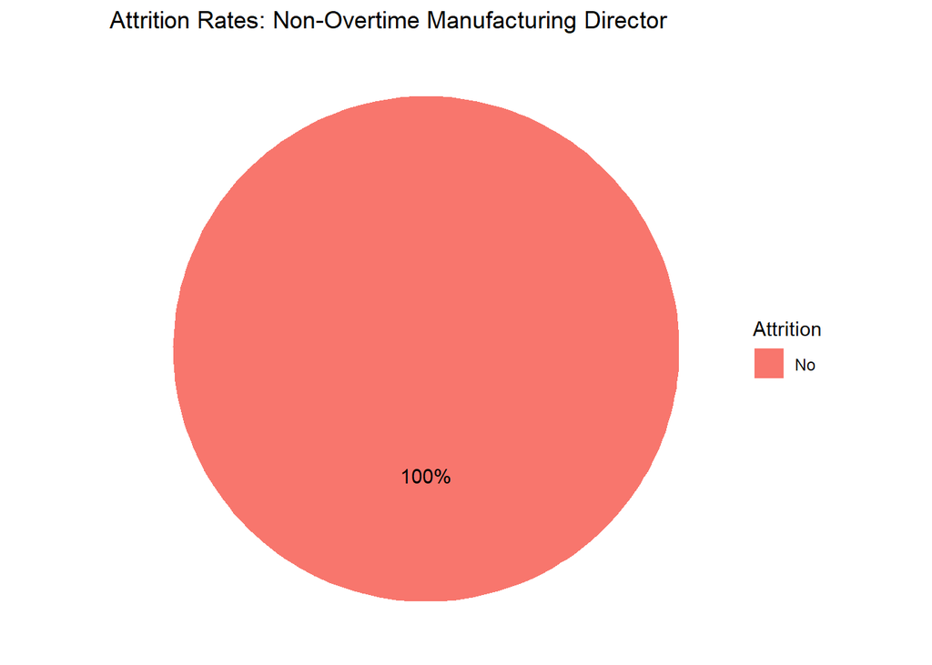

```r
#No OT
data <- data.frame(a=ManuNOOT$Attrition)
data <- data %>%
  group_by(a) %>%
  count() %>%
  ungroup() %>%
  mutate(per=`n`/sum(`n`)) %>%
  arrange(desc(a))
data$label <- scales::percent(data$per)
ggplot(data=data)+
  geom_bar(aes(x="", y=per, fill=a), stat="identity", width = 1)+
  coord_polar("y", start=0)+
  theme_void()+
  geom_text(aes(x=1, y = cumsum(per) - per/2, label=label)) +
  labs(title = "Attrition Rates: Non-Overtime Manufacturing Director",fill = "Attrition")
```

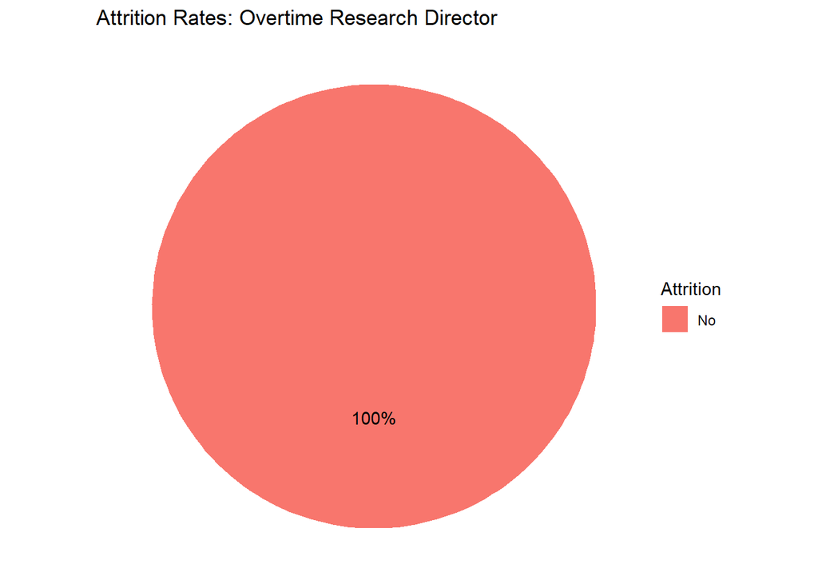

```r
#Plot Pie charts for Research Director
#OT
data <- data.frame(a=ResearchDirectorOT$Attrition)
data <- data %>%
  group_by(a) %>%
  count() %>%
  ungroup() %>%
  mutate(per=`n`/sum(`n`)) %>%
  arrange(desc(a))
data$label <- scales::percent(data$per)
ggplot(data=data)+
  geom_bar(aes(x="", y=per, fill=a), stat="identity", width = 1)+
  coord_polar("y", start=0)+
  theme_void()+
  geom_text(aes(x=1, y = cumsum(per) - per/2, label=label)) +
  labs(title = "Attrition Rates: Overtime Research Director",fill = "Attrition")
```

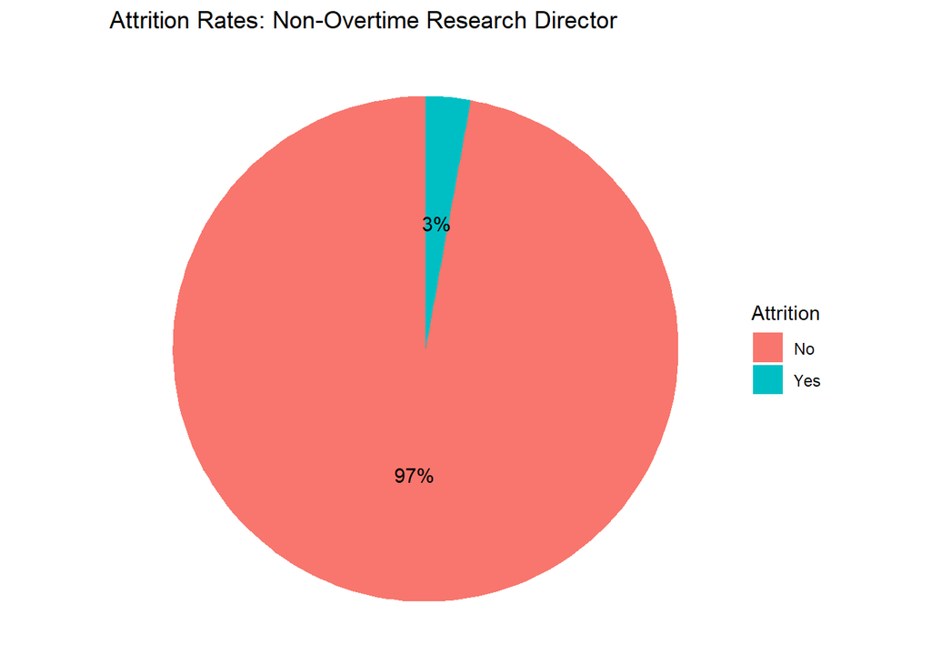

```r
#No OT
data <- data.frame(a=ResearchDirectorNOOT$Attrition)
data <- data %>%
  group_by(a) %>%
  count() %>%
  ungroup() %>%
  mutate(per=`n`/sum(`n`)) %>%
  arrange(desc(a))
data$label <- scales::percent(data$per)
ggplot(data=data)+
  geom_bar(aes(x="", y=per, fill=a), stat="identity", width = 1)+
  coord_polar("y", start=0)+
  theme_void()+
  geom_text(aes(x=1, y = cumsum(per) - per/2, label=label)) +
  labs(title = "Attrition Rates: Non-Overtime Research Director",fill = "Attrition")
```

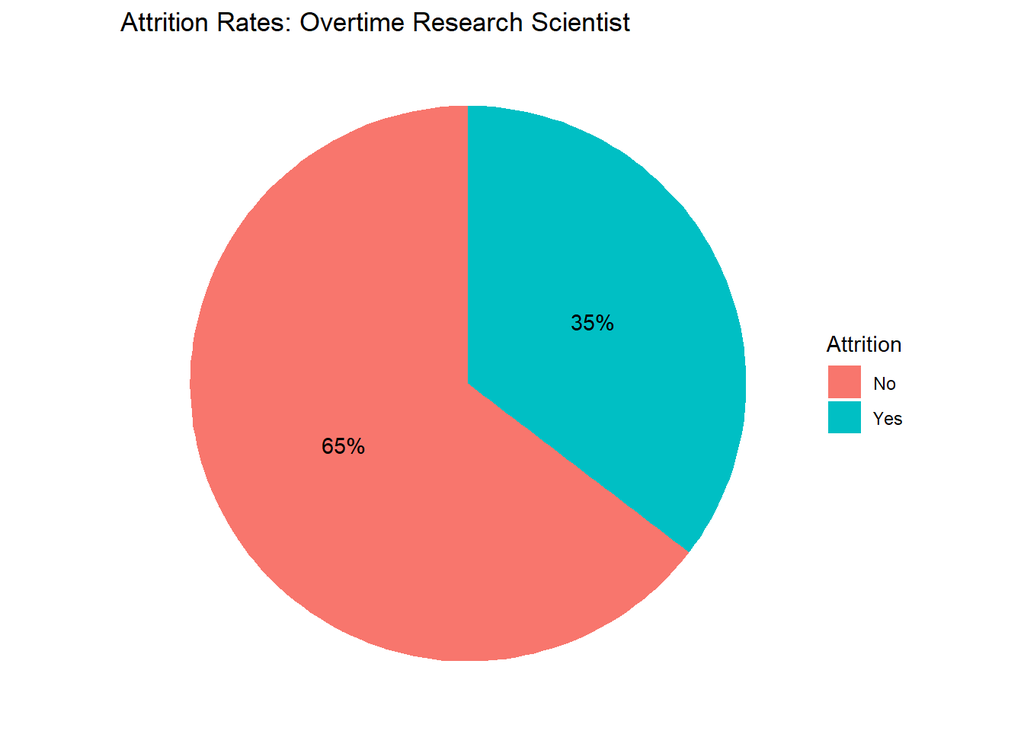

```r
#Plot Pie charts for Research Scientist
#OT
data <- data.frame(a=ResearchScientistOT$Attrition)
data <- data %>%
  group_by(a) %>%
  count() %>%
  ungroup() %>%
  mutate(per=`n`/sum(`n`)) %>%
  arrange(desc(a))
data$label <- scales::percent(data$per)
ggplot(data=data)+
  geom_bar(aes(x="", y=per, fill=a), stat="identity", width = 1)+
  coord_polar("y", start=0)+
  theme_void()+
  geom_text(aes(x=1, y = cumsum(per) - per/2, label=label)) +
  labs(title = "Attrition Rates: Overtime Research Scientist",fill = "Attrition")
```

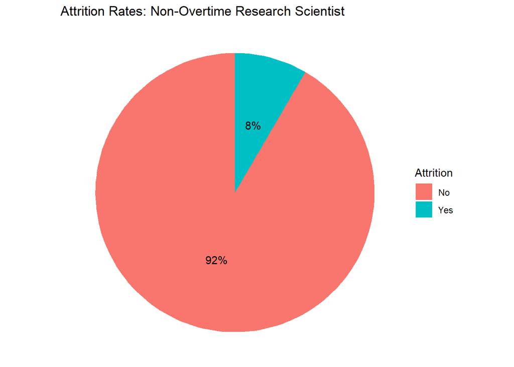

```r
#No OT
data <- data.frame(a=ResearchScientistNOOT$Attrition)
data <- data %>%
  group_by(a) %>%
  count() %>%
  ungroup() %>%
  mutate(per=`n`/sum(`n`)) %>%
  arrange(desc(a))
data$label <- scales::percent(data$per)
ggplot(data=data)+
  geom_bar(aes(x="", y=per, fill=a), stat="identity", width = 1)+
  coord_polar("y", start=0)+
  theme_void()+
  geom_text(aes(x=1, y = cumsum(per) - per/2, label=label)) +
  labs(title = "Attrition Rates: Non-Overtime Research Scientist",fill = "Attrition")
```

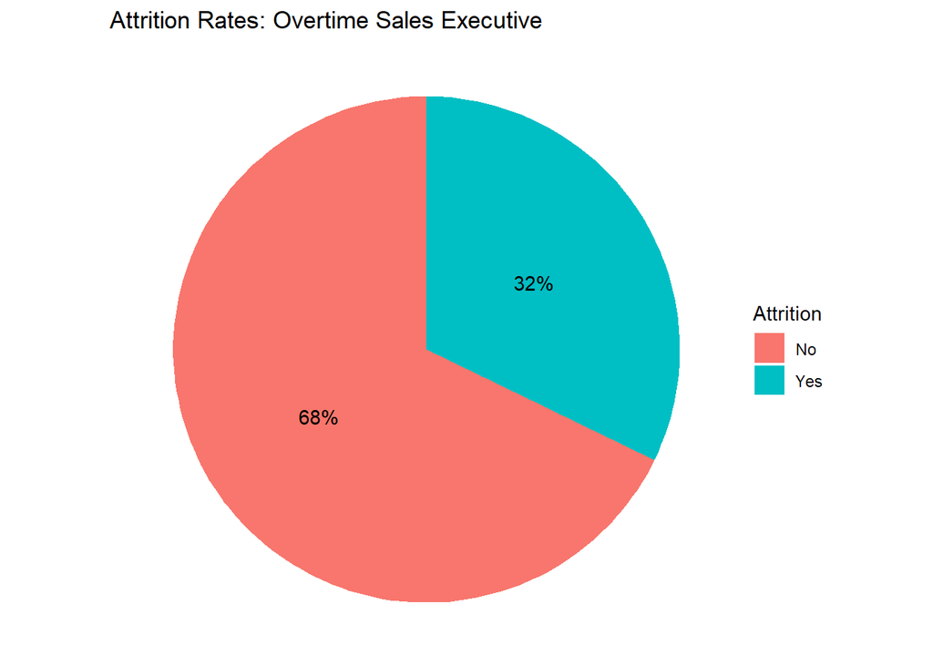

```r
#Plot Pie charts for Sales Executive
#OT
data <- data.frame(a=SalesExecOT$Attrition)
data <- data %>%
  group_by(a) %>%
  count() %>%
  ungroup() %>%
  mutate(per=`n`/sum(`n`)) %>%
  arrange(desc(a))
data$label <- scales::percent(data$per)
ggplot(data=data)+
  geom_bar(aes(x="", y=per, fill=a), stat="identity", width = 1)+
  coord_polar("y", start=0)+
  theme_void()+
  geom_text(aes(x=1, y = cumsum(per) - per/2, label=label)) +
  labs(title = "Attrition Rates: Overtime Sales Executive",fill = "Attrition")
```

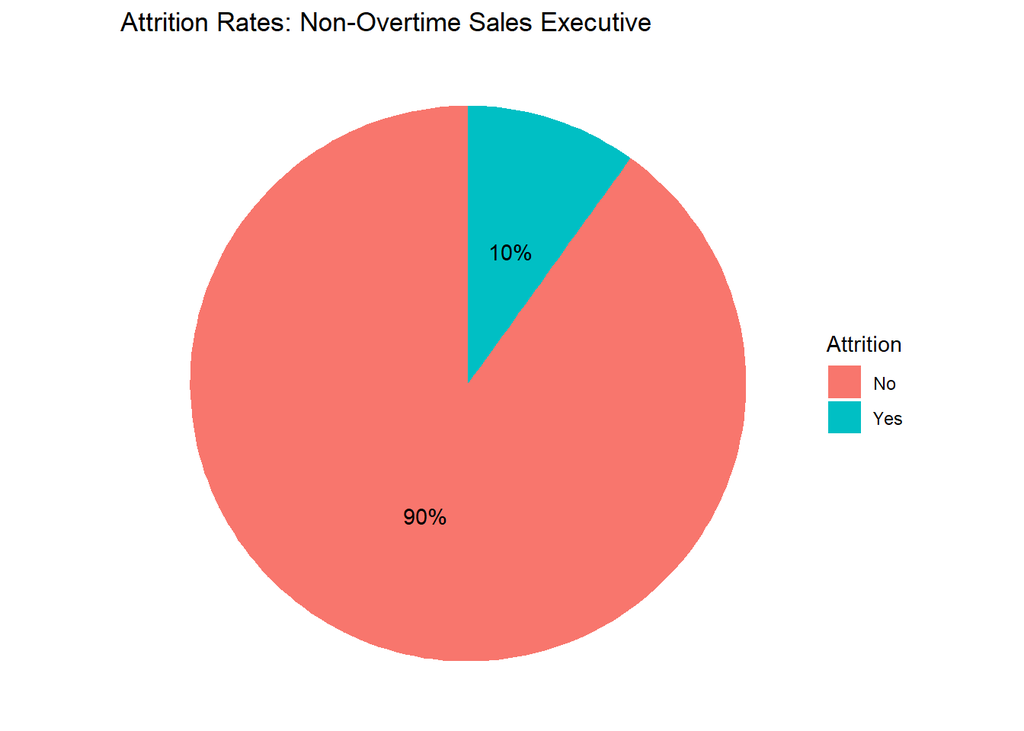

```r
#No OT
data <- data.frame(a=SalesExecNOOT$Attrition)
data <- data %>%
  group_by(a) %>%
  count() %>%
  ungroup() %>%
  mutate(per=`n`/sum(`n`)) %>%
  arrange(desc(a))
data$label <- scales::percent(data$per)
ggplot(data=data)+
  geom_bar(aes(x="", y=per, fill=a), stat="identity", width = 1)+
  coord_polar("y", start=0)+
  theme_void()+
  geom_text(aes(x=1, y = cumsum(per) - per/2, label=label)) +
  labs(title = "Attrition Rates: Non-Overtime Sales Executive",fill = "Attrition")
```

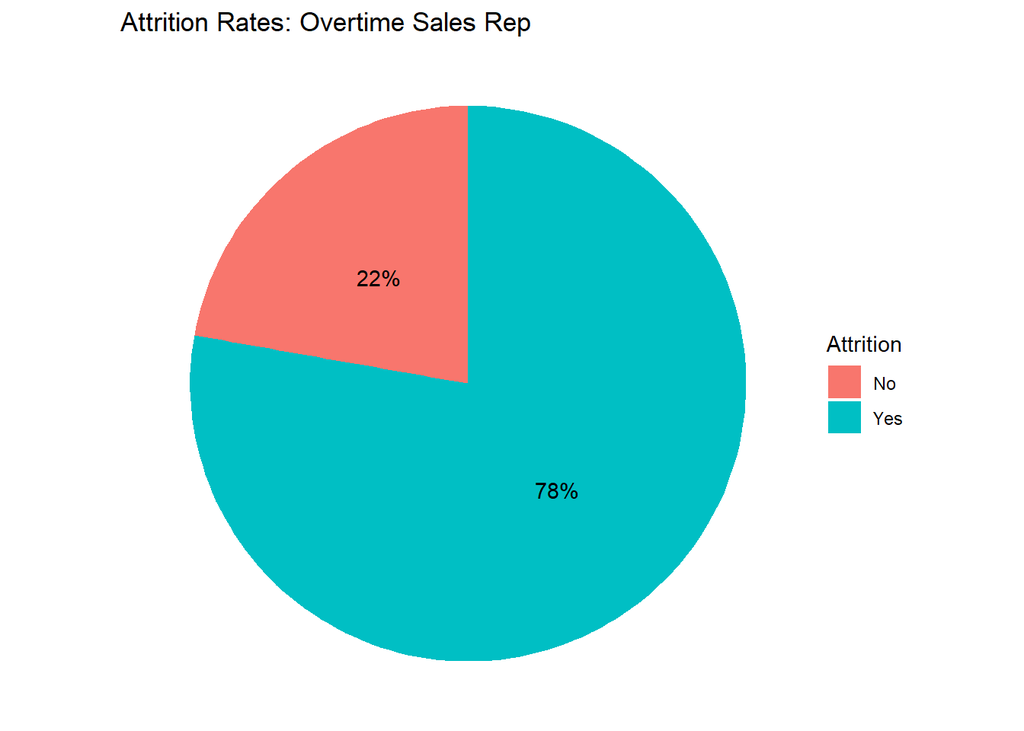

```r
#Plot Pie charts for Sales Rep
#OT
data <- data.frame(a=SalesRepOT$Attrition)
data <- data %>%
  group_by(a) %>%
  count() %>%
  ungroup() %>%
  mutate(per=`n`/sum(`n`)) %>%
  arrange(desc(a))
data$label <- scales::percent(data$per)
ggplot(data=data)+
  geom_bar(aes(x="", y=per, fill=a), stat="identity", width = 1)+
  coord_polar("y", start=0)+
  theme_void()+
  geom_text(aes(x=1, y = cumsum(per) - per/2, label=label)) +
  labs(title = "Attrition Rates: Overtime Sales Rep",fill = "Attrition")
```

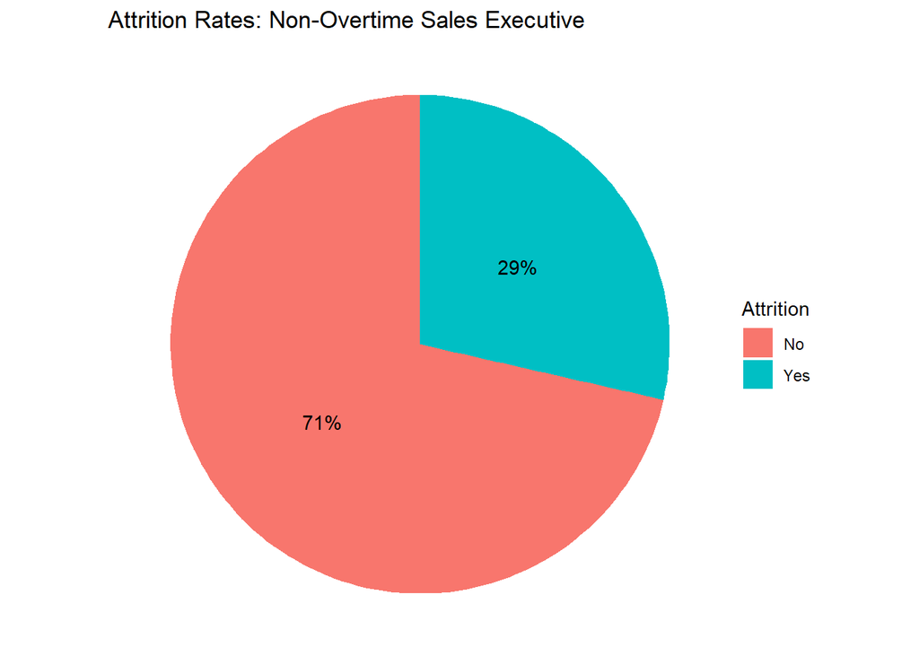

```r
#No OT
data <- data.frame(a=SalesRepNOOT$Attrition)
data <- data %>%
  group_by(a) %>%
  count() %>%
  ungroup() %>%
  mutate(per=`n`/sum(`n`)) %>%
  arrange(desc(a))
data$label <- scales::percent(data$per)
ggplot(data=data)+
  geom_bar(aes(x="", y=per, fill=a), stat="identity", width = 1)+
  coord_polar("y", start=0)+
  theme_void()+
  geom_text(aes(x=1, y = cumsum(per) - per/2, label=label)) +
  labs(title = "Attrition Rates: Non-Overtime Sales Executive",fill = "Attrition")
```

#Split into Stock Option Subsets for Plotting

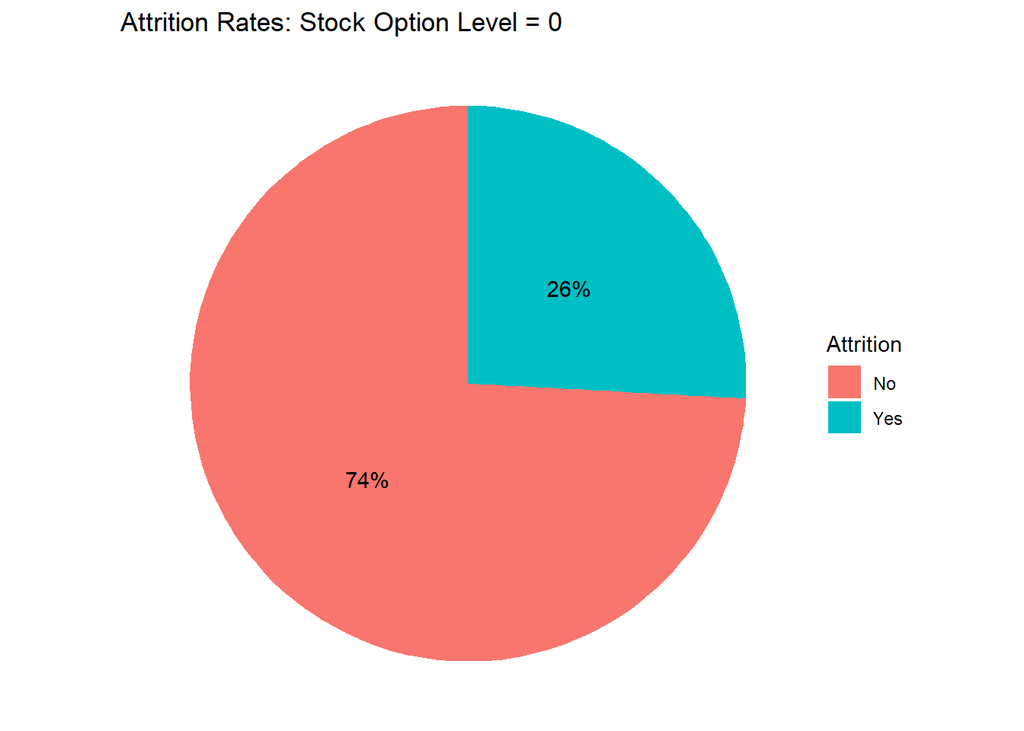

```r
Options0 = CaseStudy %>% filter(StockOptionLevel == "0")
Options1 = CaseStudy %>% filter(StockOptionLevel == "1")
Options2 = CaseStudy %>% filter(StockOptionLevel == "2")
Options3 = CaseStudy %>% filter(StockOptionLevel == "3")

#Plot Pie chart for Stock Option Level 0
data <- data.frame(a=Options0$Attrition)
data <- data %>%
  group_by(a) %>%
  count() %>%
  ungroup() %>%
  mutate(per=`n`/sum(`n`)) %>%
  arrange(desc(a))
data$label <- scales::percent(data$per)
ggplot(data=data)+
  geom_bar(aes(x="", y=per, fill=a), stat="identity", width = 1)+
  coord_polar("y", start=0)+
  theme_void()+
  geom_text(aes(x=1, y = cumsum(per) - per/2, label=label)) +
  labs(title = "Attrition Rates: Stock Option Level = 0",fill = "Attrition")
```

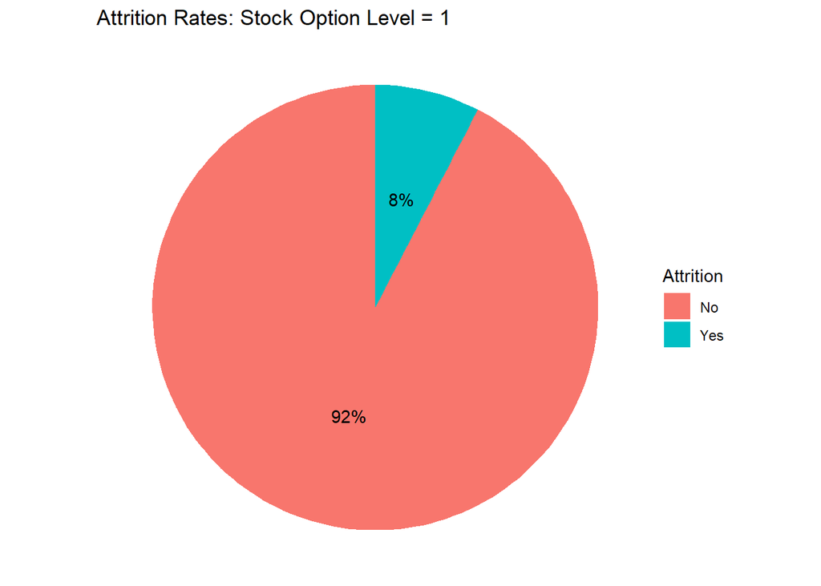

```r
#Plot Pie chart for Stock Option Level 1
data <- data.frame(a=Options1$Attrition)
data <- data %>%
  group_by(a) %>%
  count() %>%
  ungroup() %>%
  mutate(per=`n`/sum(`n`)) %>%
  arrange(desc(a))
data$label <- scales::percent(data$per)
ggplot(data=data)+
  geom_bar(aes(x="", y=per, fill=a), stat="identity", width = 1)+
  coord_polar("y", start=0)+
  theme_void()+
  geom_text(aes(x=1, y = cumsum(per) - per/2, label=label)) +
  labs(title = "Attrition Rates: Stock Option Level = 1",fill = "Attrition")
```

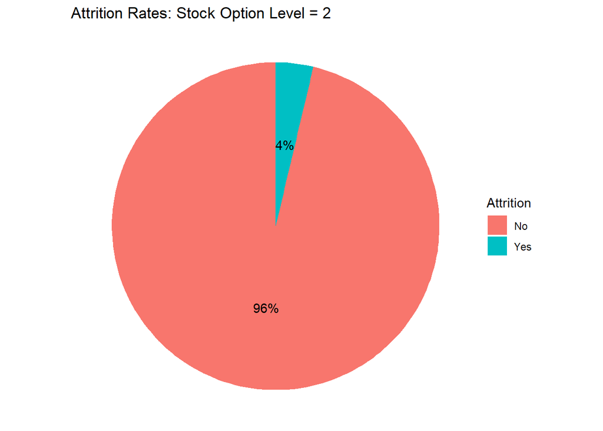

```r
#Plot Pie chart for Stock Option Level 2
data <- data.frame(a=Options2$Attrition)
data <- data %>%
  group_by(a) %>%
  count() %>%
  ungroup() %>%
  mutate(per=`n`/sum(`n`)) %>%
  arrange(desc(a))
data$label <- scales::percent(data$per)
ggplot(data=data)+
  geom_bar(aes(x="", y=per, fill=a), stat="identity", width = 1)+
  coord_polar("y", start=0)+
  theme_void()+
  geom_text(aes(x=1, y = cumsum(per) - per/2, label=label)) +
  labs(title = "Attrition Rates: Stock Option Level = 2",fill = "Attrition")
```

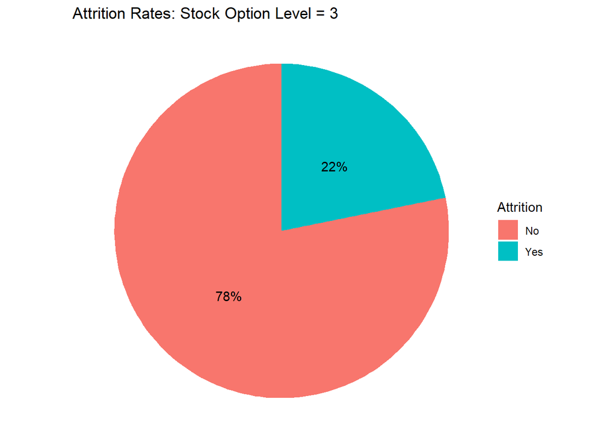

```r
#Plot Pie chart for Stock Option Level 3
data <- data.frame(a=Options3$Attrition)
data <- data %>%
  group_by(a) %>%
  count() %>%
  ungroup() %>%
  mutate(per=`n`/sum(`n`)) %>%
  arrange(desc(a))
data$label <- scales::percent(data$per)
ggplot(data=data)+
  geom_bar(aes(x="", y=per, fill=a), stat="identity", width = 1)+
  coord_polar("y", start=0)+
  theme_void()+
  geom_text(aes(x=1, y = cumsum(per) - per/2, label=label)) +
  labs(title = "Attrition Rates: Stock Option Level = 3",fill = "Attrition")
```

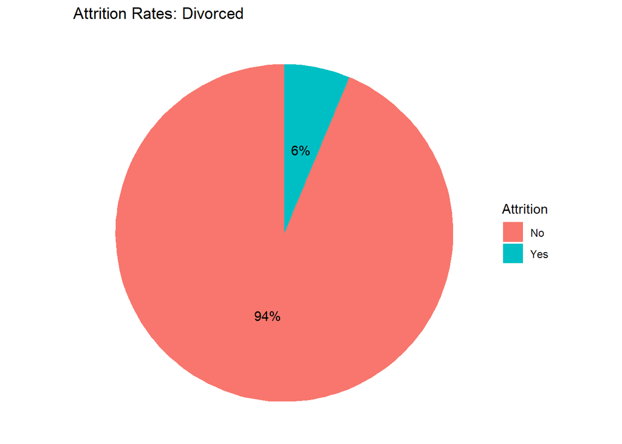

```r
##Marital Status
#Split into Marital Status Subsets for Plotting
Divorced = CaseStudy %>% filter(MaritalStatus == "Divorced")
Married = CaseStudy %>% filter(MaritalStatus == "Married")
Single = CaseStudy %>% filter(MaritalStatus == "Single")

#Plot Pie chart for Divorced
data <- data.frame(a=Divorced$Attrition)
data <- data %>%
  group_by(a) %>%
  count() %>%
  ungroup() %>%
  mutate(per=`n`/sum(`n`)) %>%
  arrange(desc(a))
data$label <- scales::percent(data$per)
ggplot(data=data)+
  geom_bar(aes(x="", y=per, fill=a), stat="identity", width = 1)+
  coord_polar("y", start=0)+
  theme_void()+
  geom_text(aes(x=1, y = cumsum(per) - per/2, label=label)) +
  labs(title = "Attrition Rates: Divorced",fill = "Attrition")
```

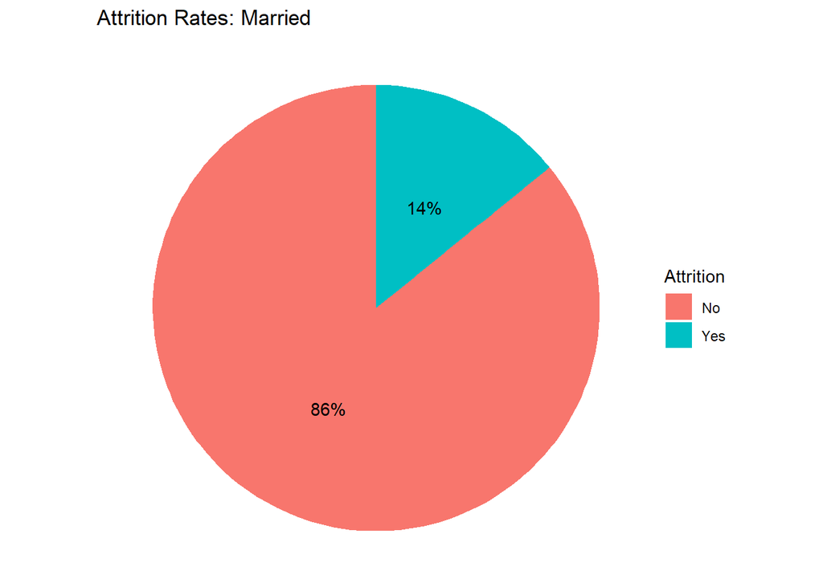

```r
#Plot Pie chart for Married
data <- data.frame(a=Married$Attrition)
data <- data %>%
  group_by(a) %>%
  count() %>%
  ungroup() %>%
  mutate(per=`n`/sum(`n`)) %>%
  arrange(desc(a))
data$label <- scales::percent(data$per)
ggplot(data=data)+
  geom_bar(aes(x="", y=per, fill=a), stat="identity", width = 1)+
  coord_polar("y", start=0)+
  theme_void()+
  geom_text(aes(x=1, y = cumsum(per) - per/2, label=label)) +
  labs(title = "Attrition Rates: Married",fill = "Attrition")
```

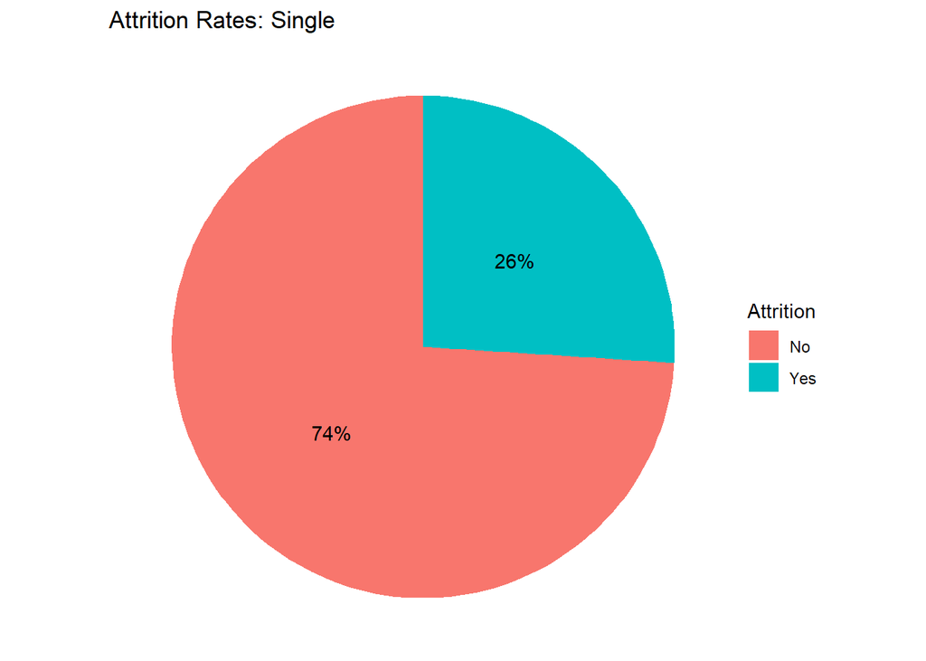

```r
#Plot Pie chart for Married
data <- data.frame(a=Single$Attrition)
data <- data %>%
  group_by(a) %>%
  count() %>%
  ungroup() %>%
  mutate(per=`n`/sum(`n`)) %>%
  arrange(desc(a))
data$label <- scales::percent(data$per)
ggplot(data=data)+
  geom_bar(aes(x="", y=per, fill=a), stat="identity", width = 1)+
  coord_polar("y", start=0)+
  theme_void()+
  geom_text(aes(x=1, y = cumsum(per) - per/2, label=label)) +
  labs(title = "Attrition Rates: Single",fill = "Attrition")
```

#Split into Work/Life Balance Subsets for Plotting

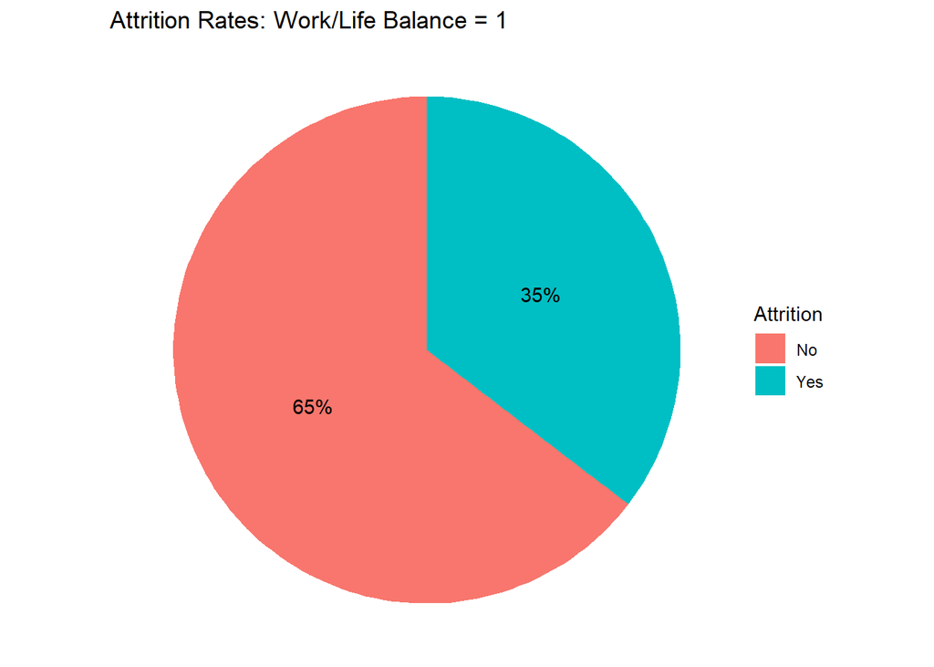

```r
WorkLife1 = CaseStudy %>% filter(WorkLifeBalance == 1)
WorkLife2 = CaseStudy %>% filter(WorkLifeBalance == 2)
WorkLife3 = CaseStudy %>% filter(WorkLifeBalance == 3)
WorkLife4 = CaseStudy %>% filter(WorkLifeBalance == 4)

#Plot Pie chart for Work Life Balance = 1
data <- data.frame(a=WorkLife1$Attrition)
data <- data %>%
  group_by(a) %>%
  count() %>%
  ungroup() %>%
  mutate(per=`n`/sum(`n`)) %>%
  arrange(desc(a))
data$label <- scales::percent(data$per)
ggplot(data=data)+
  geom_bar(aes(x="", y=per, fill=a), stat="identity", width = 1)+
  coord_polar("y", start=0)+
  theme_void()+
  geom_text(aes(x=1, y = cumsum(per) - per/2, label=label)) +
  labs(title = "Attrition Rates: Work/Life Balance = 1",fill = "Attrition")
```

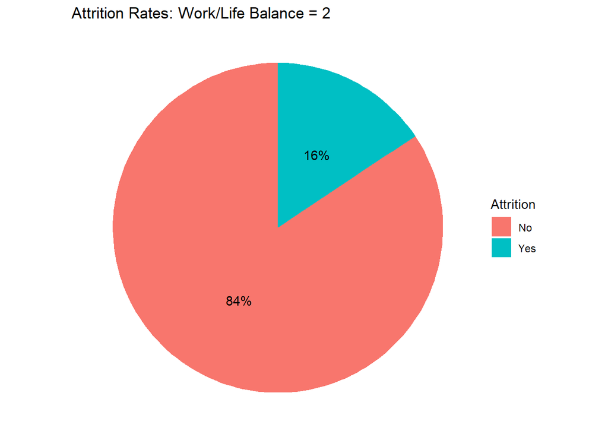

```r
#Plot Pie chart for Work Life Balance = 2
data <- data.frame(a=WorkLife2$Attrition)
data <- data %>%
  group_by(a) %>%
  count() %>%
  ungroup() %>%
  mutate(per=`n`/sum(`n`)) %>%
  arrange(desc(a))
data$label <- scales::percent(data$per)
ggplot(data=data)+
  geom_bar(aes(x="", y=per, fill=a), stat="identity", width = 1)+
  coord_polar("y", start=0)+
  theme_void()+
  geom_text(aes(x=1, y = cumsum(per) - per/2, label=label)) +
  labs(title = "Attrition Rates: Work/Life Balance = 2",fill = "Attrition")
```

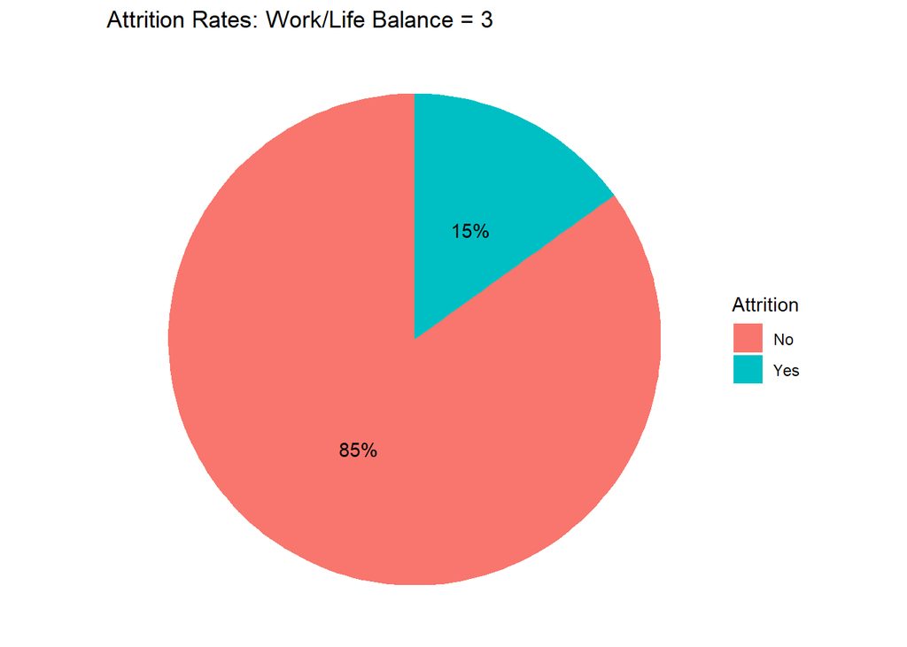

```r
#Plot Pie chart for Work Life Balance = 3
data <- data.frame(a=WorkLife3$Attrition)
data <- data %>%
  group_by(a) %>%
  count() %>%
  ungroup() %>%
  mutate(per=`n`/sum(`n`)) %>%
  arrange(desc(a))
data$label <- scales::percent(data$per)
ggplot(data=data)+
  geom_bar(aes(x="", y=per, fill=a), stat="identity", width = 1)+
  coord_polar("y", start=0)+
  theme_void()+
  geom_text(aes(x=1, y = cumsum(per) - per/2, label=label)) +
  labs(title = "Attrition Rates: Work/Life Balance = 3",fill = "Attrition")
```

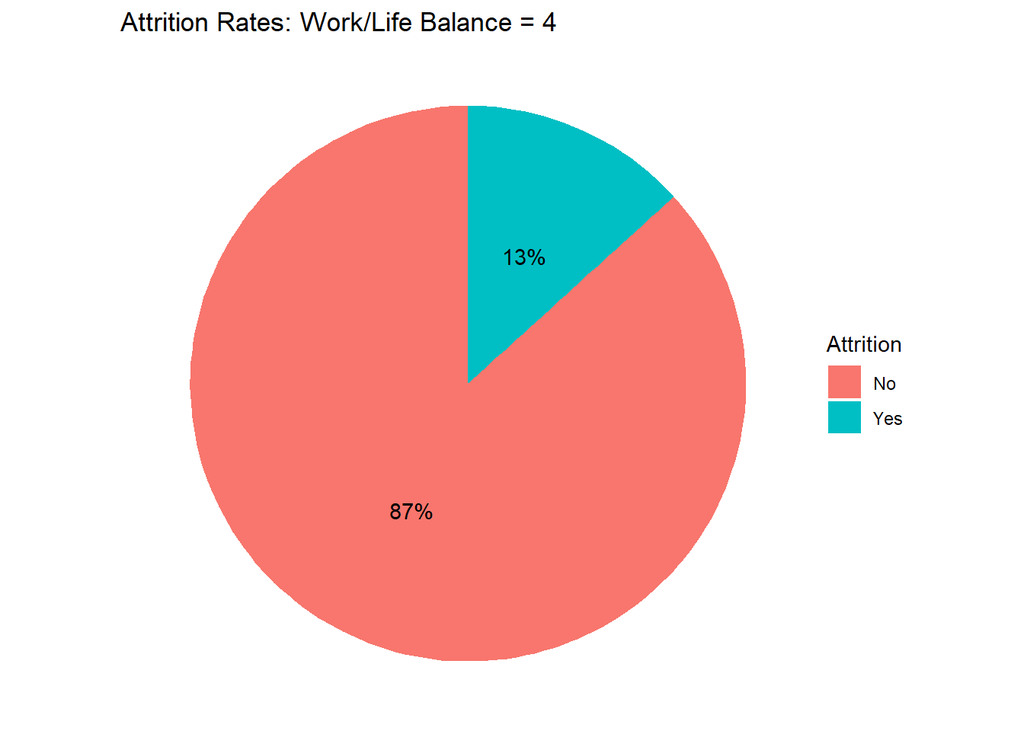

```r
#Plot Pie chart for Work Life Balance = 4
data <- data.frame(a=WorkLife4$Attrition)
data <- data %>%
  group_by(a) %>%
  count() %>%
  ungroup() %>%
  mutate(per=`n`/sum(`n`)) %>%
  arrange(desc(a))
data$label <- scales::percent(data$per)
ggplot(data=data)+
  geom_bar(aes(x="", y=per, fill=a), stat="identity", width = 1)+
  coord_polar("y", start=0)+
  theme_void()+
  geom_text(aes(x=1, y = cumsum(per) - per/2, label=label)) +
  labs(title = "Attrition Rates: Work/Life Balance = 4",fill = "Attrition")
```

#Split into Gender Subsets for Plotting

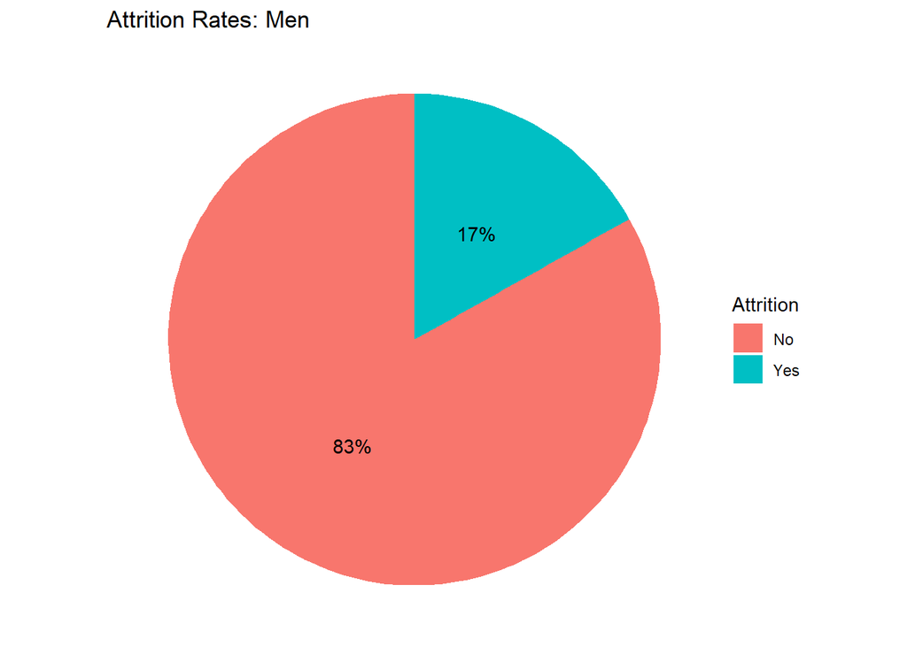

```r
Male = CaseStudy %>% filter(Gender == "Male")
Female = CaseStudy %>% filter(Gender == "Female")

#Plot Pie chart for Men
data <- data.frame(a=Male$Attrition)
data <- data %>%
  group_by(a) %>%
  count() %>%
  ungroup() %>%
  mutate(per=`n`/sum(`n`)) %>%
  arrange(desc(a))
data$label <- scales::percent(data$per)
ggplot(data=data)+
  geom_bar(aes(x="", y=per, fill=a), stat="identity", width = 1)+
  coord_polar("y", start=0)+
  theme_void()+
  geom_text(aes(x=1, y = cumsum(per) - per/2, label=label)) +
  labs(title = "Attrition Rates: Men",fill = "Attrition")
```

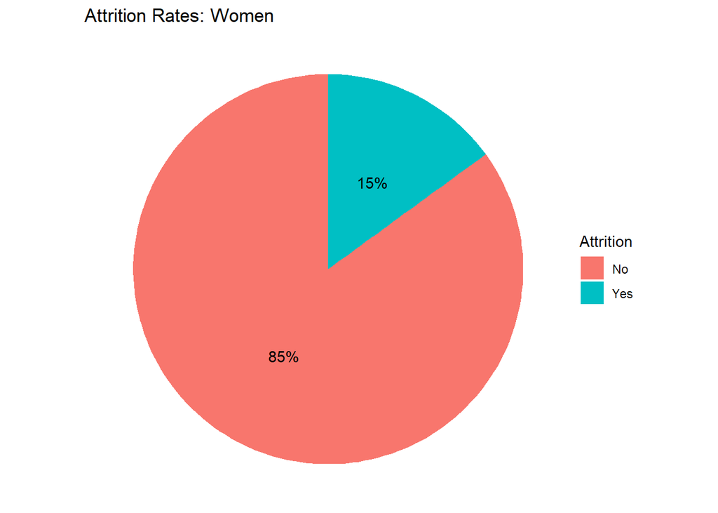

```r
#Plot Pie chart for Women
data <- data.frame(a=Female$Attrition)
data <- data %>%
  group_by(a) %>%
  count() %>%
  ungroup() %>%
  mutate(per=`n`/sum(`n`)) %>%
  arrange(desc(a))
data$label <- scales::percent(data$per)
ggplot(data=data)+
  geom_bar(aes(x="", y=per, fill=a), stat="identity", width = 1)+
  coord_polar("y", start=0)+
  theme_void()+
  geom_text(aes(x=1, y = cumsum(per) - per/2, label=label)) +
  labs(title = "Attrition Rates: Women",fill = "Attrition")
```

# Monthly Income Boxplot

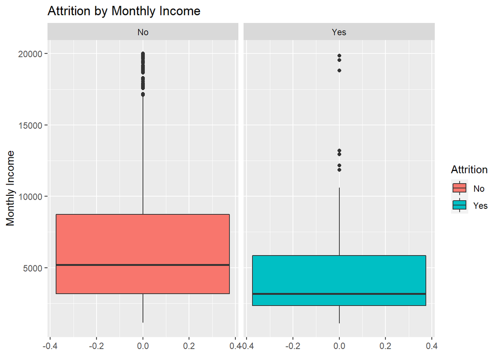

```r
CaseStudy %>%
  ggplot(aes(y = MonthlyIncome,fill = Attrition)) +
  geom_boxplot() +
  facet_wrap(~Attrition) +
  labs(title = "Attrition by Monthly Income",y = "Monthly Income")
```

# Total Working Years

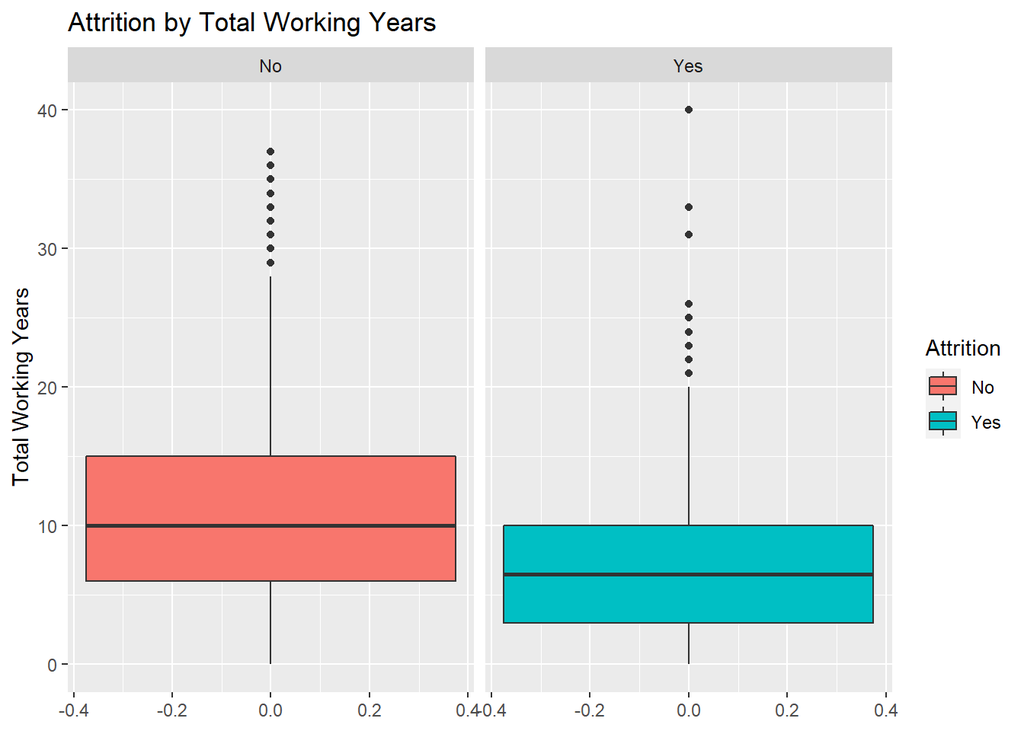

```r
CaseStudy %>% ggplot(aes(y = TotalWorkingYears,fill = Attrition)) +
  geom_boxplot() +
  facet_wrap(~Attrition) +
  labs(title = "Attrition by Total Working Years",y = "Total Working Years")
```

##KNN

```r
testmodel = train.kknn(Attrition ~ JobRole_OT + MonthlyIncomeHL + JobInvolvement +
                         WorkLifeBalance + TotalWorkHL + JobLevel + StockOptionLevel +
                         MaritalStatus + Gender,
                       data = CaseStudy,kmax = 15,
                       kernel = c("rectangular","triangular","epanechnikov","gaussian","rank","optimal"),scale = TRUE)
model = train.kknn(Attrition ~ JobRole_OT + MonthlyIncomeHL + JobInvolvement +
                     WorkLifeBalance + TotalWorkHL + JobLevel + StockOptionLevel +
                     MaritalStatus + Gender,
                   data = CaseStudy,ks = testmodel$best.parameters$k,
                   kernel = testmodel$best.parameters$kernel,scale = TRUE)
preds = predict(model,newdata = CaseStudy)
CM = confusionMatrix(preds,CaseStudy$Attrition)
CM
```

```
## Confusion Matrix and Statistics
##
##           Reference
## Prediction  No Yes
##        No  726  26
##        Yes   4 114
##
##                Accuracy : 0.9655
##                  95% CI : (0.9511, 0.9766)
##     No Information Rate : 0.8391
##     P-Value [Acc > NIR] : < 2.2e-16
##
##                   Kappa : 0.8637
##
##  Mcnemar's Test P-Value : 0.000126
##
##             Sensitivity : 0.9945
##             Specificity : 0.8143
##          Pos Pred Value : 0.9654
##          Neg Pred Value : 0.9661
##              Prevalence : 0.8391
##          Detection Rate : 0.8345
##    Detection Prevalence : 0.8644
##       Balanced Accuracy : 0.9044
##
##        'Positive' Class : No
##
```

##Set up the data for the competition set

```r
NoAttrition[,names] <- lapply(NoAttrition[,names],factor,ordered = TRUE)
#Create new variables for job OT & Job Gender
NoAttrition <- NoAttrition %>% mutate(JobRole_OT = paste(JobRole,OverTime,sep = "_"))
NoAttrition$JobRole_OT = as.factor(NoAttrition$JobRole_OT)

NoAttrition$MonthlyIncomeHL = as.factor(if_else(NoAttrition$MonthlyIncome <= IncomeSum[2],"Lowest",
                                               if_else(NoAttrition$MonthlyIncome <= IncomeSum[3],"Medium/Low",
                                                       if_else(NoAttrition$MonthlyIncome <= IncomeSum[4],"Medium/High","High"))))

NoAttrition$TotalWorkHL = as.factor(if_else(NoAttrition$TotalWorkingYears <= TotalWorkSum[2],"<=6",
                                           if_else(NoAttrition$TotalWorkingYears <= TotalWorkSum[3],"6< <=10",
                                                   if_else(NoAttrition$TotalWorkingYears <= TotalWorkSum[5],"10< <=15",">15"))))
```

## Run predictions on the competition set using kknn

```r
testmodel = train.kknn(Attrition ~ JobRole_OT + MonthlyIncomeHL + JobInvolvement +
                         WorkLifeBalance + TotalWorkHL + JobLevel + StockOptionLevel +
                         MaritalStatus + Gender,
                       data = CaseStudy,kmax = 25,
                       kernel = c("rectangular","triangular","epanechnikov","gaussian","rank","optimal"),scale = TRUE)
model = train.kknn(Attrition ~ JobRole_OT + MonthlyIncomeHL + JobInvolvement +
                     WorkLifeBalance + TotalWorkHL + JobLevel + StockOptionLevel +
                     MaritalStatus + Gender,
                   data = CaseStudy,ks = testmodel$best.parameters$k,
                   kernel = testmodel$best.parameters$kernel,scale = TRUE)
NoAttrition$predictions = predict(model,newdata = NoAttrition)
```

##Write the data to a csv for submission

```r
NoAttritionSubmit = NoAttrition[,c("ID","predictions")]
path_out = "C:\\Users\\Steve Mann\\OneDrive\\Desktop\\"
write.csv(NoAttritionSubmit,"C:\\Users\\Steve Mann\\OneDrive\\Desktop\\Case2PredictionsMann_Attrition.csv")
```

##Write a model to predict Monthly Income. ##Model was adjusted manually by stepwise regression. It is likely there are other variables ##or ineraction variables that would be considered significant, however, as the mean RMSE on ##1000 iterations of 70/30 train/test split is ~1000, I decided to stop.

#Summary statistics of model

```r
summary(model)
```

```
##
## Call:
## lm(formula = MonthlyIncome ~ ., data = train)
##
## Residuals:
##     Min      1Q  Median      3Q     Max
## -3131.9  -641.2   -80.6   658.1  4226.6
##
## Coefficients: (1 not defined because of singularities)
##                                          Estimate Std. Error t value Pr(>|t|)
## (Intercept)                              8602.742    256.598  33.526  < 2e-16
## OverTimeYes                             -1629.488    393.950  -4.136 4.05e-05
## TotalWorkingYears                          54.325      9.693   5.605 3.21e-08
## JobRole_OTHealthcare Representative_Yes  1355.610    435.961   3.109 0.001965
## JobRole_OTHuman Resources_No            -1076.187    325.930  -3.302 0.001019
## JobRole_OTHuman Resources_Yes             424.318    526.679   0.806 0.420772
## JobRole_OTLaboratory Technician_No      -1334.563    237.728  -5.614 3.06e-08
## JobRole_OTLaboratory Technician_Yes       466.706    388.840   1.200 0.230526
## JobRole_OTManager_No                     3228.893    330.135   9.781  < 2e-16
## JobRole_OTManager_Yes                    5432.804    552.726   9.829  < 2e-16
## JobRole_OTManufacturing Director_No       148.690    221.048   0.673 0.501428
## JobRole_OTManufacturing Director_Yes     1875.832    453.017   4.141 3.97e-05
## JobRole_OTResearch Director_No           3656.360    285.365  12.813  < 2e-16
## JobRole_OTResearch Director_Yes          4994.252    489.447  10.204  < 2e-16
## JobRole_OTResearch Scientist_No         -1194.090    251.031  -4.757 2.48e-06
## JobRole_OTResearch Scientist_Yes          525.075    353.951   1.483 0.138487
## JobRole_OTSales Executive_No               47.540    193.241   0.246 0.805757
## JobRole_OTSales Executive_Yes            1801.086    391.265   4.603 5.10e-06
## JobRole_OTSales Representative_No       -1371.486    303.155  -4.524 7.35e-06
## JobRole_OTSales Representative_Yes             NA         NA      NA       NA
## JobLevel.L                               8733.825    323.038  27.036  < 2e-16
## JobLevel.Q                                703.546    177.526   3.963 8.31e-05
## JobLevel.C                               -559.850    142.983  -3.916 0.000101
## JobLevel^4                                203.502    123.951   1.642 0.101168
##
## (Intercept)                             ***
## OverTimeYes                             ***
## TotalWorkingYears                       ***
## JobRole_OTHealthcare Representative_Yes **
## JobRole_OTHuman Resources_No            **
```

[output cut: 10 more lines]

```
## JobRole_OTResearch Scientist_Yes
## JobRole_OTSales Executive_No
## JobRole_OTSales Executive_Yes           ***
## JobRole_OTSales Representative_No       ***
## JobRole_OTSales Representative_Yes
## JobLevel.L                              ***
## JobLevel.Q                              ***
## JobLevel.C                              ***
## JobLevel^4
## ---
## Signif. codes:  0 '***' 0.001 '**' 0.01 '*' 0.05 '.' 0.1 ' ' 1
##
## Residual standard error: 1034 on 587 degrees of freedom
## Multiple R-squared:  0.948,  Adjusted R-squared:  0.946
## F-statistic:   486 on 22 and 587 DF,  p-value: < 2.2e-16
```

```r
MeanRMSE = colMeans(RootMSE)
MeanR_Square = colMeans(R_Square)
MeanRMSE
```

```
## [1] 1022.87
```

```r
MeanR_Square
```

```
## [1] 0.9503083
```

```r
NoSalary
```

[output not shown]

[output cut: 2393 more lines]

```r
newdata <- NoSalary[,c("OverTime","TotalWorkingYears","JobRole_OT","JobLevel")]
model <- lm(MonthlyIncome ~ .,data = data)
newdata$predictions <- model %>% predict(newdata)
newdata$ID = NoSalary$ID
newdata_submit = newdata[,c("ID","predictions")]
path_out = "C:\\Users\\Steve Mann\\OneDrive\\Desktop\\"
write.csv(newdata_submit,"C:\\Users\\Steve Mann\\OneDrive\\Desktop\\Case2PredictionsMann_Salary.csv")
newdata_submit
```

```
##       ID predictions
## 1    871    5591.842
## 2    872    2786.537
## 3    873   13033.049
## 4    874    2569.055
## 5    875    2661.681
## 6    876    4973.767
## 7    877    5638.156
## 8    878    2430.115
## 9    879    3018.104
## 10   880   13378.418
## 11   881    9788.094
## 12   882    2661.681
## 13   883    5545.529
## 14   884    5499.216
```

[output cut: 286 more lines]